# Analysing Learner Speech and Resulting Applications for EFL Classrooms - A corpus-based contrastive analysis of vowel production of L1 English speakers and L1 Japanese learners of English (Part 2)

Martin Schweinberger

2022-06-13

# 1 Introduction

This R Notebook shows the analysis of high front and back vowels produced by Japanese learners and L1 speakers of English. This notebook contains the second part of the analysis which focuses on data processing, visualization, and analysis.

## 1.1 Preparation

install packages

```r
# install
install.packages("bookdown")
install.packages("tidyverse")
install.packages("here")
install.packages("viridis")
install.packages("phonR")
install.packages("vowels")
install.packages("ggridges")
install.packages("sm")
install.packages("adehabitatHR")
install.packages("lme4")
install.packages("car")
install.packages("sjPlot")
install.packages("report")
install.packages("flextable")
install.packages("glmmTMB")
```

load packages

```r
# set options
options("scipen" = 100, "digits" = 12) # suppress math annotation
# activate packages
library(bookdown)
library(tidyverse)
library(here)
library(viridis)
library(phonR)
library(vowels)
library(ggridges)
library(sm)
library(adehabitatHR)
library(lme4)
library(car)
library(sjPlot)
library(report)
library(flextable)
```

load data

```r
# load .rda data
vdf  <- base::readRDS(file = here::here("data", "vdf.rda")) %>%
  dplyr::mutate(type = stringr::str_replace_all(file, "^[A-Z]{2,}_([A-Z]{3,3})_.*", "\\1"),
                speaker = stringr::str_replace_all(file, ".*_([0-9]{3,3})_.*", "\\1")) %>%
  dplyr::mutate(tgender = stringr::str_replace_all(path, ".*F[3-7]{1,1}_([fm]{1,1})_[a-z]{2,2}$", "\\1"),
                tformants = stringr::str_replace_all(path, ".*(F[3-7]{1,1})_[fm]{1,1}_[a-z]{2,2}$", "\\1"),
                tvariety = stringr::str_remove_all(path, ".*_"))
# inspect
nrow(vdf); head(vdf)
```

```
## [1] 332330
```

```
## # A tibble: 6 × 17
## # Rowwise:
##   id     tmin  tmax label word  file      midpoint    F1    F2    F3 vowel path
##   <chr> <dbl> <dbl> <chr> <chr> <chr>        <dbl> <dbl> <dbl> <dbl> <chr> <chr>
## 1 1      1.78  1.83 eI    say   SM_ENS_P…     1.81  405. 1797  2785. eɪ    D:/U…
## 2 1      3.59  3.72 I     the   SM_ENS_P…     3.66  346. 1980. 2768. ɪ     D:/U…
## 3 1      4.13  4.17 @     that  SM_ENS_P…     4.15  272. 1634. 2654. ə     D:/U…
## 4 1      6.71  7    I     with  SM_ENS_P…     6.86  317. 2089. 2958. ɪ     D:/U…
## 5 1      8.31  8.46 e     debt  SM_ENS_P…     8.39  686. 1979. 2690. e     D:/U…
## 6 1     16.0  16.0  U     good  SM_ENS_P…    16.0   470. 2309. 3104. ʊ     D:/U…
## # … with 5 more variables: type <chr>, speaker <chr>, tgender <chr>,
## #   tformants <chr>, tvariety <chr>
```

# 2 Data Processing

## 2.1 Load Biodata

```r
bio <- read.delim(here::here("data", "biodata_icnale.txt"), header = T, sep = "\t") %>%
  dplyr::filter(stringr::str_detect(Code, "JPN|ENS")) %>%
  dplyr::mutate(type = stringr::str_replace_all(Code, "^[A-Z]{2,}_([A-Z]{3,3})_.*", "\\1"),
                speaker = stringr::str_replace_all(Code, ".*_([0-9]{3,3}).*", "\\1"),
                Sex = tolower(Sex)) %>%
  dplyr::rename(gender = Sex)
bio[bio=="N/A"]<-NA
# inspect
head(bio)
```

```
##         Code Country PTJ1..wds. PTJ2..wds. SMK1..wds. SMK2..wds. Self.Ev gender
## 1 SM_ENS_001 ENS_GBR        134        141        126        139    <NA>      m
## 2 SM_ENS_002 ENS_USA        207        186        159        163    <NA>      m
## 3 SM_ENS_003 ENS_CAN        116        132        124        123    <NA>      m
## 4 SM_ENS_004 ENS_USA        161        174        163        170    <NA>      m
## 5 SM_ENS_005 ENS_AUS        145        174        177        181    <NA>      m
## 6 SM_ENS_006 ENS_USA        203        196        208        190    <NA>      m
##   Age Grade.Degree Yrs.of.Stay....Yrs. ENS.Type  Major..Occupation Acad..Genre
## 1  32         [BA]                <NA>   Others         Translator        <NA>
## 2  34         [BA]                <NA>  Teacher                ALT        <NA>
## 3  63         [MA]                <NA>  Teacher College Instructor        <NA>
## 4  34         [MA]                <NA>  Teacher  College Professor        <NA>
## 5  25         [BA]                <NA>  Teacher English Instructor        <NA>
## 6  23         <NA>                <NA>  Student           Language  Humanities
##   Test Score  VST CEFR INTM INSM INTM.INSM INTM.INSM.1 Primary Secondary
```

[output cut: 20 more lines]

## 2.2 Join data sets

join formant and biodata

```r
fdat <- dplyr::left_join(vdf, bio, by = c("type", "speaker"))  %>%
  # filter out di- and triphthongs
  dplyr::mutate(nv = nchar(stringr::str_remove_all(label, ":"))) %>%
  dplyr::filter(nv == 1) %>%
  dplyr::filter(gender == tgender) %>%
  # remove  ref speakers with l1-var other than genam or gb
  dplyr::mutate(tvariety = dplyr::case_when(Country == "ENS_GBR" ~ "gb",
                                            Country == "ENS_CAN" ~ "us",
                                            Country == "ENS_USA" ~ "us",
                                             TRUE ~ tvariety)) %>%
  dplyr::filter(type == "JPN" | type == "ENS" & Country == "ENS_CAN" | Country == "ENS_GBR" | Country == "ENS_USA")
# inspect
head(fdat)
```

```
## # A tibble: 6 × 53
## # Rowwise:
##   id     tmin  tmax label word  file      midpoint    F1    F2    F3 vowel path
##   <chr> <dbl> <dbl> <chr> <chr> <chr>        <dbl> <dbl> <dbl> <dbl> <chr> <chr>
## 1 2      3.59  3.72 I     the   SM_ENS_P…     3.66  335. 1720. 2565. ɪ     D:/U…
## 2 2      4.13  4.17 @     that  SM_ENS_P…     4.15  306. 1696. 2634. ə     D:/U…
## 3 2      6.71  7    I     with  SM_ENS_P…     6.86  312. 1544. 2658  ɪ     D:/U…
## 4 2      8.31  8.46 e     debt  SM_ENS_P…     8.39  553. 1436. 2349. e     D:/U…
## 5 2     16.0  16.0  U     good  SM_ENS_P…    16.0   478. 2264. 2871. ʊ     D:/U…
## 6 2     16.4  16.6  @     to    SM_ENS_P…    16.5   433. 1419. 2630. ə     D:/U…
## # … with 41 more variables: type <chr>, speaker <chr>, tgender <chr>,
## #   tformants <chr>, tvariety <chr>, Code <chr>, Country <chr>,
## #   PTJ1..wds. <int>, PTJ2..wds. <int>, SMK1..wds. <int>, SMK2..wds. <int>,
## #   Self.Ev <chr>, gender <chr>, Age <int>, Grade.Degree <chr>,
## #   Yrs.of.Stay....Yrs. <chr>, ENS.Type <chr>, Major..Occupation <chr>,
## #   Acad..Genre <chr>, Test <chr>, Score <chr>, VST <chr>, CEFR <chr>,
## #   INTM <chr>, INSM <chr>, INTM.INSM <chr>, INTM.INSM.1 <chr>, …
```

data inspection

```r
table(fdat$label, fdat$tvariety, fdat$type)
```

```
## , ,  = ENS
##
##
##         gb    us
##   @   6420   825
##   {    595  8080
##   6      0   465
##   A:    30     0
##   e    985     0
##   E      0  3355
##   I   2305 10505
##   i:   725  5300
##   O:     5    80
##   Q    290   740
##   u      0  1000
##   U    675  1075
##   u:   335  9140
##   V     80 11535
##
## , ,  = JPN
##
##
##         gb    us
##   @  13500   385
##   {   2495  3120
##   6      0   625
##   A:    10     0
##   e   2320     0
##   E      0  1490
##   I   8930  9550
##   i:  2395  3620
##   O:   100    80
##   Q    555   425
##   u      0   675
##   U   2045  1175
##   u:  1470  4835
##   V    410  7415
```

## 2.3 Load Reference Data

**GenAm**

[Yang, Byunggon. 1996. A comparative study of American English and Korean vowels produced by male and female speakers. *Journal of Phonetics* 24: 245–261.](http://fonetiks.info/bgyang/db/96jp.pdf)

```r
ame <- read.delim(here::here("data/reference", "GenAm.txt"), sep = "\t", header = T) %>%
  dplyr::mutate(label = dplyr::case_when(item == "had" ~ "{",
                                         item == "heed" ~ "i:",
                                         item == "hid" ~ "I",
                                         item == "head" ~ "E",
                                         item == "hard" ~ "6",
                                         item == "whod" ~ "u:",
                                         item == "hood" ~ "U",
                                         item == "hoard" ~ "O:",
                                         item == "hud" ~ "V",
                                         item == "hod" ~ "Q",
                                         TRUE ~ "other"),
                gender = dplyr::case_when(sex == "female" ~ "f",
                                          TRUE ~ "m")) %>%
  dplyr::filter(label != "other") %>%
  dplyr::group_by(label, gender) %>%
  dplyr::summarise(target_f1 = mean(F1_Hz),
                   target_f2 = mean(F2_Hz),
                   target_f3 = mean(F3_Hz)) %>%
  dplyr::mutate(tvariety = "us")
# inspect data
head(ame)
```

```
## # A tibble: 6 × 6
## # Groups:   label [3]
##   label gender target_f1 target_f2 target_f3 tvariety
##   <chr> <chr>      <dbl>     <dbl>     <dbl> <chr>
## 1 {     f           831.     2044.     2949. us
## 2 {     m           680.     1754.     2507. us
## 3 6     f           769.     1278.     2546. us
## 4 6     m           639.     1059.     2323. us
## 5 E     f           513.     2559.     2987. us
## 6 E     m           473.     2073.     2655. us
```

**SSB**

[Deterding, David 2009. The Formants of Monophthong Vowels in Standard Southern British English Pronunciation. *Journal of the International Phonetic Association* 27, 1-2: 47-55. doi:10.1017/S0025100300005417](http://journals.cambridge.org/download.php?file=%2F7775_45AD5CD7849D3B7634A613DE6E61C294_journals__IPA_IPA27_1-2_S0025100300005417a.pdf&cover=Y&code=0639c34593b21cb18a9e7b504bdd5319)

```r
bre <- read.delim(here::here("data/reference", "SSB.txt"), sep = "\t", header = T) %>%
  dplyr::mutate(label = dplyr::case_when(item == "had" ~ "{",
                                         item == "heed" ~ "i:",
                                         item == "hid" ~ "I",
                                         item == "head" ~ "e",
                                         item == "hard" ~ "A:",
                                         item == "whod" ~ "u:",
                                         item == "hood" ~ "U",
                                         item == "hoard" ~ "O:",
                                         item == "hud" ~ "V",
                                         item == "hod" ~ "Q",
                                         TRUE ~ "other"),
                gender = dplyr::case_when(sex == "female" ~ "f",
                                          TRUE ~ "m")) %>%
  dplyr::filter(label != "other") %>%
  dplyr::group_by(label, gender) %>%
  dplyr::summarise(target_f1 = mean(F1_Hz),
                   target_f2 = mean(F2_Hz),
                   target_f3 = mean(F3_Hz)) %>%
  dplyr::mutate(tvariety = "gb")
# inspect data
head(bre)
```

```
## # A tibble: 6 × 6
## # Groups:   label [3]
##   label gender target_f1 target_f2 target_f3 tvariety
##   <chr> <chr>      <dbl>     <dbl>     <dbl> <chr>
## 1 {     f          1018.     1799.     2869  gb
## 2 {     m           690.     1550.     2463. gb
## 3 A:    f           910.     1316.     2841. gb
## 4 A:    m           646.     1155.     2490. gb
## 5 e     f           719      2063.     2997  gb
## 6 e     m           494      1650      2547. gb
```

Combine reference and obs data

```r
ref <- rbind(ame, bre)
fdat <- dplyr::left_join(fdat, ref) %>%
  dplyr::filter(!is.na(target_f1)) %>%
  dplyr::mutate(edist = sqrt((F1-target_f1)^2 + (F2-target_f2)^2))
# inspect
head(fdat)
```

```
## # A tibble: 6 × 57
## # Rowwise:
##   id     tmin  tmax label word  file      midpoint    F1    F2    F3 vowel path
##   <chr> <dbl> <dbl> <chr> <chr> <chr>        <dbl> <dbl> <dbl> <dbl> <chr> <chr>
## 1 2      3.59  3.72 I     the   SM_ENS_P…     3.66  335. 1720. 2565. ɪ     D:/U…
## 2 2      6.71  7    I     with  SM_ENS_P…     6.86  312. 1544. 2658  ɪ     D:/U…
## 3 2      8.31  8.46 e     debt  SM_ENS_P…     8.39  553. 1436. 2349. e     D:/U…
## 4 2     16.0  16.0  U     good  SM_ENS_P…    16.0   478. 2264. 2871. ʊ     D:/U…
## 5 2     19.1  19.2  e     debt  SM_ENS_P…    19.1   616. 1784. 2509. e     D:/U…
## 6 2     35.6  35.9  I     the   SM_ENS_P…    35.8   442. 2073. 2886. ɪ     D:/U…
## # … with 45 more variables: type <chr>, speaker <chr>, tgender <chr>,
## #   tformants <chr>, tvariety <chr>, Code <chr>, Country <chr>,
## #   PTJ1..wds. <int>, PTJ2..wds. <int>, SMK1..wds. <int>, SMK2..wds. <int>,
## #   Self.Ev <chr>, gender <chr>, Age <int>, Grade.Degree <chr>,
## #   Yrs.of.Stay....Yrs. <chr>, ENS.Type <chr>, Major..Occupation <chr>,
## #   Acad..Genre <chr>, Test <chr>, Score <chr>, VST <chr>, CEFR <chr>,
## #   INTM <chr>, INSM <chr>, INTM.INSM <chr>, INTM.INSM.1 <chr>, …
```

Determine best fit (f3:f7)

```r
fdat <- fdat %>%
  dplyr::arrange(file, tmin, tvariety, tformants) %>%
  dplyr::group_by(file, tmin) %>%
  dplyr::slice(which.min(edist))
# inspect
head(fdat)
```

```
## # A tibble: 6 × 57
## # Groups:   file, tmin [6]
##   id     tmin  tmax label word  file      midpoint    F1    F2    F3 vowel path
##   <chr> <dbl> <dbl> <chr> <chr> <chr>        <dbl> <dbl> <dbl> <dbl> <chr> <chr>
## 1 2      3.59  3.72 I     the   SM_ENS_P…     3.66  335. 1720. 2565. ɪ     D:/U…
## 2 4      6.71  7    I     with  SM_ENS_P…     6.86  312. 1665. 2713. ɪ     D:/U…
## 3 2      8.31  8.46 e     debt  SM_ENS_P…     8.39  553. 1436. 2349. e     D:/U…
## 4 2     16.0  16.0  U     good  SM_ENS_P…    16.0   478. 2264. 2871. ʊ     D:/U…
## 5 2     19.1  19.2  e     debt  SM_ENS_P…    19.1   616. 1784. 2509. e     D:/U…
## 6 2     35.6  35.9  I     the   SM_ENS_P…    35.8   442. 2073. 2886. ɪ     D:/U…
## # … with 45 more variables: type <chr>, speaker <chr>, tgender <chr>,
## #   tformants <chr>, tvariety <chr>, Code <chr>, Country <chr>,
## #   PTJ1..wds. <int>, PTJ2..wds. <int>, SMK1..wds. <int>, SMK2..wds. <int>,
## #   Self.Ev <chr>, gender <chr>, Age <int>, Grade.Degree <chr>,
## #   Yrs.of.Stay....Yrs. <chr>, ENS.Type <chr>, Major..Occupation <chr>,
## #   Acad..Genre <chr>, Test <chr>, Score <chr>, VST <chr>, CEFR <chr>,
## #   INTM <chr>, INSM <chr>, INTM.INSM <chr>, INTM.INSM.1 <chr>, …
```

remove vowels other than I and i: or U and u:

```r
# reduce words
fdat <- fdat %>%
  dplyr::filter(nchar(word) < 9,
                word != "the") %>%
  # bark normalization
  dplyr::mutate(barkF1 = normBark(F1),
                barkF2 = normBark(F2)) %>%
  # lobanov normalization
  dplyr::ungroup() %>%
  dplyr::mutate(fspeaker = paste0(type, speaker, collaspe = "")) %>%
  dplyr::group_by(type, tvariety, gender) %>%
  dplyr::mutate(lobF1 = scale(F1),
                lobF2 = scale(F2)) %>%
  # remove superfluous columns
  dplyr::select(-path, -PTJ1..wds., -PTJ2..wds., -SMK1..wds., -SMK2..wds., -Self.Ev,
                -Grade.Degree, -Acad..Genre, -VST, -CEFR, -INTM, -INSM, -INTM.INSM,
                -INTM.INSM.1, -Primary, -Secondary, -College, -Inschool, -Outschool,
                -Reading, -Writing, -NS, -Presentation, -EssayW, -nv) %>%
  dplyr::filter(label == "U" | label == "u:" | label == "I" | label == "i:")
# inspect
head(fdat)
```

```
## # A tibble: 6 × 37
## # Groups:   type, tvariety, gender [2]
##   id     tmin  tmax label word  file      midpoint    F1    F2    F3 vowel type
##   <chr> <dbl> <dbl> <chr> <chr> <chr>        <dbl> <dbl> <dbl> <dbl> <chr> <chr>
## 1 4      6.71  7    I     with  SM_ENS_P…     6.86  312. 1665. 2713. ɪ     ENS
## 2 2     16.0  16.0  U     good  SM_ENS_P…    16.0   478. 2264. 2871. ʊ     ENS
## 3 12     5.33  5.41 I     to    SM_ENS_P…     5.37  491. 1844. 2596. ɪ     ENS
## 4 12     8.85  8.98 I     to    SM_ENS_P…     8.91  437. 1604. 2796. ɪ     ENS
## 5 12    10.5  10.6  I     to    SM_ENS_P…    10.6   459. 2084. 2841. ɪ     ENS
## 6 12    11.2  11.4  I     good  SM_ENS_P…    11.3   555. 1940. 2644  ɪ     ENS
## # … with 25 more variables: speaker <chr>, tgender <chr>, tformants <chr>,
## #   tvariety <chr>, Code <chr>, Country <chr>, gender <chr>, Age <int>,
## #   Yrs.of.Stay....Yrs. <chr>, ENS.Type <chr>, Major..Occupation <chr>,
## #   Test <chr>, Score <chr>, Listening <chr>, Speaking <chr>,
## #   Pronunciation <chr>, target_f1 <dbl>, target_f2 <dbl>, target_f3 <dbl>,
## #   edist <dbl>, barkF1 <dbl>, barkF2 <dbl>, fspeaker <chr>, lobF1 <dbl[,1]>,
## #   lobF2 <dbl[,1]>
```

generate overview (data before processing)

```r
tb0 <- fdat %>%
  dplyr::ungroup() %>%
  dplyr::filter(tformants == "F5",
                label == "I" | label == "i:" | label == "U" | label == "u:" ) %>%
  dplyr::group_by(type, label) %>%
  dplyr::summarise(speakers = max(length(table(speaker))),
                   obs = n()) %>%
  dplyr::mutate(speakers = max(speakers)) %>%
  tidyr::spread(label, obs) %>%
  dplyr::ungroup() %>%
  dplyr::add_row(type = "Total",
                 speakers = sum(.$speakers),
                 I = sum(.$I),
                 `i:` = sum(.$`i:`),
                 U = sum(.$U),
                 `u:` = sum(.$`u:`))
# save
write.table(tb0, here::here("tables", "tb0.txt"), sep = "\t")
# inspect
tb0
```

```
## # A tibble: 3 × 6
##   type  speakers     I  `i:`     U  `u:`
##   <chr>    <int> <int> <int> <int> <int>
## 1 ENS          3     2     2     1     3
## 2 JPN         14    16     8     4    10
## 3 Total       17    18    10     5    13
```

## 2.4 (Semi-)Manual cross-evaluation

check for inconsistencies

```r
table(fdat$label, fdat$word)
```

```
##
##      –-we   ba   be  big  bit book books boost boots  bui  but   de  did  dis
##   I     4    0  417   25   34    0     3     0     0    1   31    0   33    2
##   i:    0    1 1143    0    0    0     0     0     0    0    0    1    0    0
##   U     0    0    0    0    0    7    22     0     0    0    0    0    0    0
##   u:    0    0    0    0    0    0     0     1     1    0    0    0    0    0
##
##      dish   do  due  get gets good   he he's  hea  his  hit keep keeps  key
##   I    12   93    0   35    1   55   38    0    1   41    1    0     0    0
##   i:    0    0    0    0    0    0   81    1    1    0    0   63     1    2
##   U     0  106    2    0    0  662    0    0    0    0    0    0     0    0
##   u:    0  486    4    0    0    0    0    0    0    0    0    0     0    0
##
##       kid kids  peo push  put puts seat seats  see seep sees sets  she shits
##   I     4   22    0    0    0    0    0     0    0    0    0    1    6     2
##   i:    0    0    6    0    0    0   11    21   64    1    1    0    7     0
##   U     0    0    0    1   18    2    0     0    0    0    0    0    0     0
##   u:    0    0    0    0    0    0    0     0    0    0    0    0    0     0
##
##      shoes shops shou  sit sit- skip   so speak  stu suit  tea teeth that
##   I      0     1    0   22    1    1    0     1    0    0    0     0  223
##   i:     0     0    0    0    0    0    0    22    0    0    2     5    0
##   U      0     0    0    0    0    0    2     0    0    0    0     0    0
##   u:     6     0    1    0    0    0    0     0    3    1    0     0    0
##
##      that's that\u0081's they this   ti   to  too took  two ways   we we're
##   I       4            1  261 1305    0 1155   13    0   31    5  575     0
##   i:      0            0    0    0    1    7    0    0    1    0  815     9
##   U       0            0    0    0    0   11    0    3    0    0    0     0
##   u:      0            0    0    0    0 1994   93    0   95    0    0     0
##
##      we've weak weed week  whi  who who's who've wish with with\u0081 wood
##   I      0    0    0    0    0    0     0      0   13 1303          1    0
##   i:     2    8    2   15    1    0     0      0    0    0          0    0
##   U      0    0    0    0    0  132     0      0    0    0          0    1
##   u:     0    0    0    0    0  445     5      1    0    0          0    0
```

exclude inconsistencies

```r
fdat <- fdat %>%
  dplyr::mutate(word = stringr::str_squish(word)) %>%
  dplyr::mutate(remove = dplyr::case_when(word == "--we"  ~ "remove",
                                          word == "ba"  ~ "remove",
                                          word == "bit" & label == "6" ~ "remove",
                                          word == "books" & label == "I" ~ "remove",
                                          word == "but" & label == "I" ~ "remove",
                                          word == "bui" & label == "I" ~ "remove",
                                          word == "de" & label == "i:" ~ "remove",
                                          word == "do" & label == "6" ~ "remove",
                                          word == "do" & label == "I" ~ "remove",
                                          word == "dust" & label == "V" ~ "remove",
                                          word == "get" & label == "I" ~ "remove",
                                          word == "gets" & label == "I" ~ "remove",
                                          word == "good" & label == "I" ~ "remove",
                                          word == "hea" ~ "remove",
                                          word == "peo" ~ "remove",
                                          word == "speak" & label == "I" ~ "remove",
                                          word == "sets" & label == "I" ~ "remove",
                                          word == "shops" & label == "I" ~ "remove",
                                          word == "so" & label == "U" ~ "remove",
                                          word == "that" & label == "I" ~ "remove",
                                          word == "that's" & label == "I" ~ "remove",
                                          word == "they're" ~ "remove",
                                          word == "they" ~ "remove",
                                          word == "that\u0081's" & label == "I" ~ "remove",
                                          word == "this" & label == "O:" ~ "remove",
                                          word == "to" ~ "remove",
                                          word == "too" & label == "I" ~ "remove",
                                          word == "too" & label == "6" ~ "remove",
                                          word == "two" & label != "u:" ~ "remove",
                                          word == "ways" & label == "I" ~ "remove",
                                          word == "we're" & label == "6" ~ "remove",
                                          word == "we're" & label == "6" ~ "remove",
                                          stringr::str_detect(word, "\\W") ~ "remove",
                                          TRUE ~ "keep")) %>%
  dplyr::filter(remove != "remove")
# inspect
table(fdat$label, fdat$word)
```

```
##
##        be  big  bit book books boost boots  did  dis dish   do  due good   he
##   I   417   25   34    0     0     0     0   33    2   12    0    0    0   38
##   i: 1143    0    0    0     0     0     0    0    0    0    0    0    0   81
##   U     0    0    0    7    22     0     0    0    0    0  106    2  662    0
##   u:    0    0    0    0     0     1     1    0    0    0  486    4    0    0
##
##       his  hit keep keeps  key  kid kids push  put puts seat seats  see seep
##   I    41    1    0     0    0    4   22    0    0    0    0     0    0    0
##   i:    0    0   63     1    2    0    0    0    0    0   11    21   64    1
##   U     0    0    0     0    0    0    0    1   18    2    0     0    0    0
##   u:    0    0    0     0    0    0    0    0    0    0    0     0    0    0
##
##      sees  she shits shoes shou  sit skip speak  stu suit  tea teeth this   ti
##   I     0    6     2     0    0   22    1     0    0    0    0     0 1305    0
##   i:    1    7     0     0    0    0    0    22    0    0    2     5    0    1
##   U     0    0     0     0    0    0    0     0    0    0    0     0    0    0
##   u:    0    0     0     6    1    0    0     0    3    1    0     0    0    0
##
##       too took  two   we weak weed week  whi  who wish with wood
##   I     0    0    0  575    0    0    0    0    0   13 1303    0
##   i:    0    0    0  815    8    2   15    1    0    0    0    0
##   U     0    3    0    0    0    0    0    0  132    0    0    1
##   u:   93    0   95    0    0    0    0    0  445    0    0    0
```

## 2.5 Check durations

```r
fdat <- fdat %>%
  # duration
  dplyr::mutate(duration = tmax - tmin)
# inspect
head(fdat)
```

```
## # A tibble: 6 × 39
## # Groups:   type, tvariety, gender [2]
##   id     tmin  tmax label word  file      midpoint    F1    F2    F3 vowel type
##   <chr> <dbl> <dbl> <chr> <chr> <chr>        <dbl> <dbl> <dbl> <dbl> <chr> <chr>
## 1 4      6.71  7    I     with  SM_ENS_P…     6.86  312. 1665. 2713. ɪ     ENS
## 2 2     16.0  16.0  U     good  SM_ENS_P…    16.0   478. 2264. 2871. ʊ     ENS
## 3 12    13.6  13.7  U     good  SM_ENS_P…    13.6   609. 1093. 2669. ʊ     ENS
## 4 12    36.0  36.1  I     big   SM_ENS_P…    36.0   575. 2155. 2693. ɪ     ENS
## 5 22    24.9  24.9  U     good  SM_ENS_P…    24.9   704. 1901. 2214. ʊ     ENS
## 6 32     1.36  1.44 I     with  SM_ENS_P…     1.4   538. 1799. 2501. ɪ     ENS
## # … with 27 more variables: speaker <chr>, tgender <chr>, tformants <chr>,
## #   tvariety <chr>, Code <chr>, Country <chr>, gender <chr>, Age <int>,
## #   Yrs.of.Stay....Yrs. <chr>, ENS.Type <chr>, Major..Occupation <chr>,
## #   Test <chr>, Score <chr>, Listening <chr>, Speaking <chr>,
## #   Pronunciation <chr>, target_f1 <dbl>, target_f2 <dbl>, target_f3 <dbl>,
## #   edist <dbl>, barkF1 <dbl>, barkF2 <dbl>, fspeaker <chr>, lobF1 <dbl[,1]>,
## #   lobF2 <dbl[,1]>, remove <chr>, duration <dbl>
```

plot durations

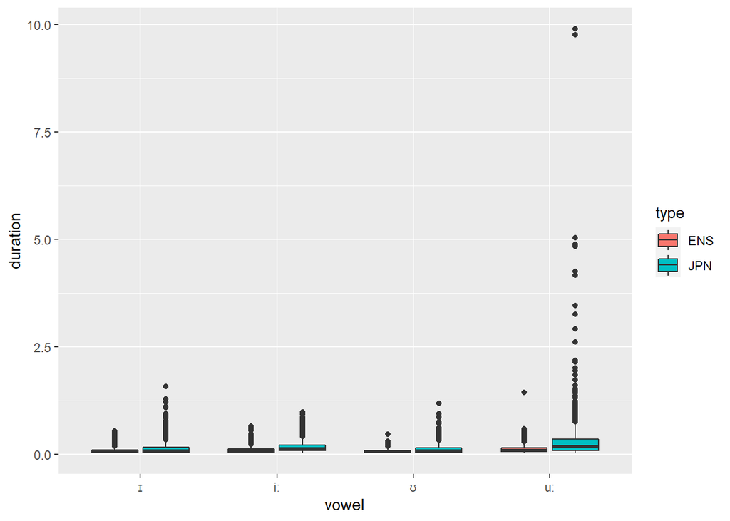

```r
fdat %>%
  ggplot(aes(x = vowel, y = duration, fill = type)) +
  geom_boxplot()
```

```r
max_durs <- fdat %>%
  dplyr::group_by(type, tvariety, vowel) %>%
  dplyr::summarise(du_min = min(duration),
                   du_max = max(duration),
                   du_ave = mean(duration),
                   du_med = median(duration),
                   du_sd = sd(duration),
                   du_2sd = sd(duration)*1.645) %>%
  dplyr::mutate(cutoff_duration = du_ave + du_2sd) %>%
  dplyr::select(type, tvariety, vowel, cutoff_duration)
# inspect
head(max_durs)
```

```
## # A tibble: 6 × 4
## # Groups:   type, tvariety [2]
##   type  tvariety vowel cutoff_duration
##   <chr> <chr>    <chr>           <dbl>
## 1 ENS   gb       ɪ               0.189
## 2 ENS   gb       iː              0.335
## 3 ENS   gb       ʊ               0.158
## 4 ENS   gb       uː              0.542
## 5 ENS   us       ɪ               0.187
## 6 ENS   us       iː              0.184
```

remove duration outliers

```r
fdat <- dplyr::left_join(fdat, max_durs) %>%
  dplyr::filter(duration <= cutoff_duration,
                ifelse(label != "A:", duration <= 0.4, duration <= 0.75))
# inspect
head(fdat); nrow(fdat)
```

```
## # A tibble: 6 × 40
## # Groups:   type, tvariety, gender [2]
##   id     tmin  tmax label word  file      midpoint    F1    F2    F3 vowel type
##   <chr> <dbl> <dbl> <chr> <chr> <chr>        <dbl> <dbl> <dbl> <dbl> <chr> <chr>
## 1 2     16.0  16.0  U     good  SM_ENS_P…     16.0  478. 2264. 2871. ʊ     ENS
## 2 12    13.6  13.7  U     good  SM_ENS_P…     13.6  609. 1093. 2669. ʊ     ENS
## 3 12    36.0  36.1  I     big   SM_ENS_P…     36.0  575. 2155. 2693. ɪ     ENS
## 4 22    24.9  24.9  U     good  SM_ENS_P…     24.9  704. 1901. 2214. ʊ     ENS
## 5 32     1.36  1.44 I     with  SM_ENS_P…      1.4  538. 1799. 2501. ɪ     ENS
## 6 32    18.5  18.5  I     with  SM_ENS_P…     18.5  830. 1641  2242. ɪ     ENS
## # … with 28 more variables: speaker <chr>, tgender <chr>, tformants <chr>,
## #   tvariety <chr>, Code <chr>, Country <chr>, gender <chr>, Age <int>,
## #   Yrs.of.Stay....Yrs. <chr>, ENS.Type <chr>, Major..Occupation <chr>,
## #   Test <chr>, Score <chr>, Listening <chr>, Speaking <chr>,
## #   Pronunciation <chr>, target_f1 <dbl>, target_f2 <dbl>, target_f3 <dbl>,
## #   edist <dbl>, barkF1 <dbl>, barkF2 <dbl>, fspeaker <chr>, lobF1 <dbl[,1]>,
## #   lobF2 <dbl[,1]>, remove <chr>, duration <dbl>, cutoff_duration <dbl>
```

```
## [1] 7547
```

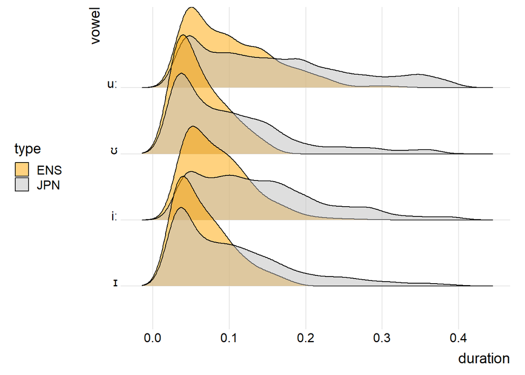

```r
dur_IiUu <-  fdat %>%
  dplyr::filter(label == "i:" | label == "I" | label == "u:" | label == "U") %>%
  ggplot(aes(y = vowel, x = duration, fill = type)) +
  geom_density_ridges(alpha = .5) +
  theme_ridges() +
  theme(legend.position = "left") +
  scale_fill_manual(values = c("orange", "gray"))
ggsave(here::here("images", "dur_IiUu.png"), height = 5,  width = 5, dpi = 320)
dur_IiUu
```

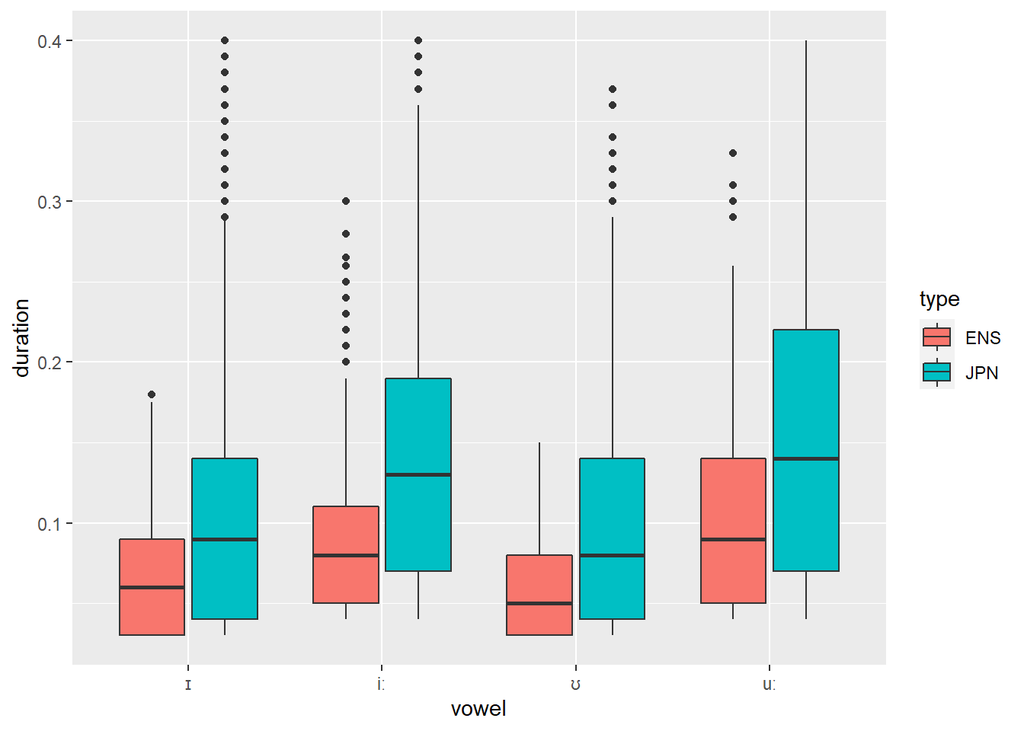

```r
fdat %>%
  ggplot(aes(x = vowel, y = duration, fill = type)) +
  geom_boxplot()
```

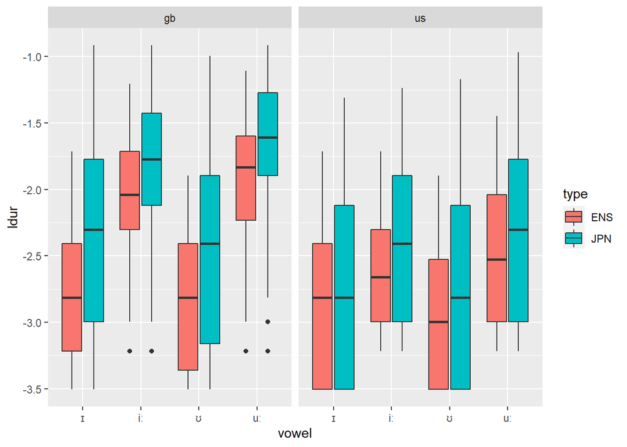

```r
fdat %>%
  dplyr::group_by(type, tvariety, vowel) %>%
  dplyr::mutate(ldur = log(duration)) %>%
  ggplot(aes(x = vowel, y = ldur, fill = type)) +
  geom_boxplot() +
  facet_grid(~tvariety)
```

## 2.6 Remove outliers

```r
nrow(fdat)
```

```
## [1] 7547
```

```r
fdat <- fdat %>%
  dplyr::group_by(type, tvariety, label) %>%
  dplyr::mutate(densF1 = sm.density(barkF1,eval.points=barkF1)$estimate,
                densF2 = sm.density(barkF2,eval.points=barkF2)$estimate,
                qnt1F1 = quantile(densF1, .25),
                qnt1F2 = quantile(densF2, .25))
```

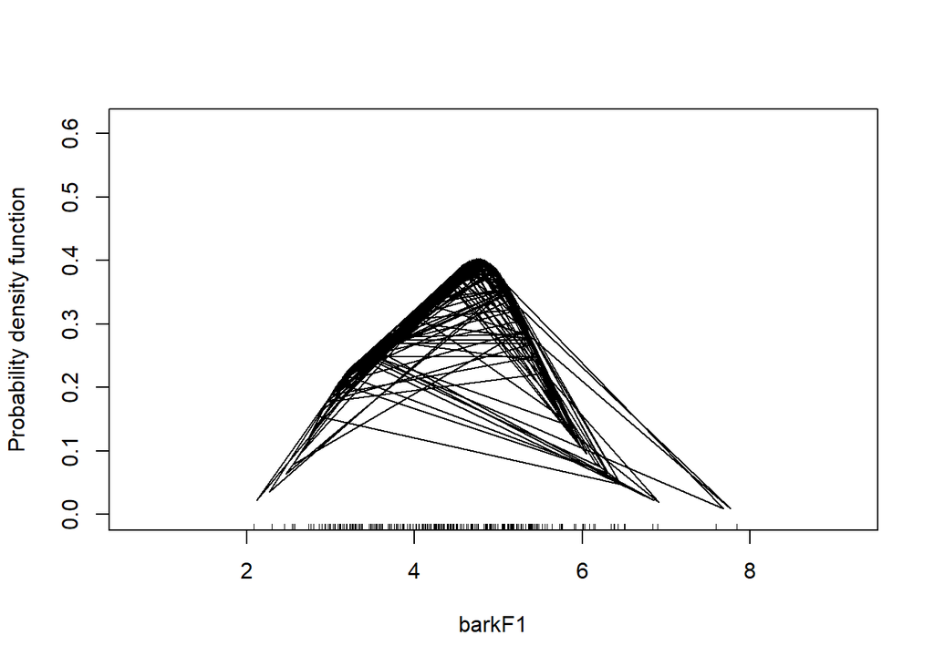

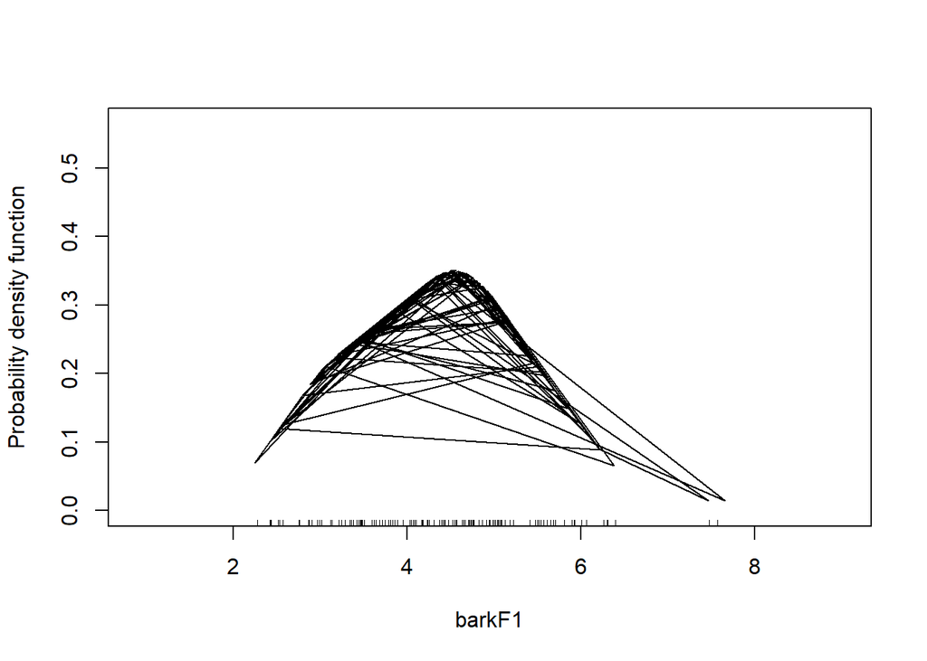

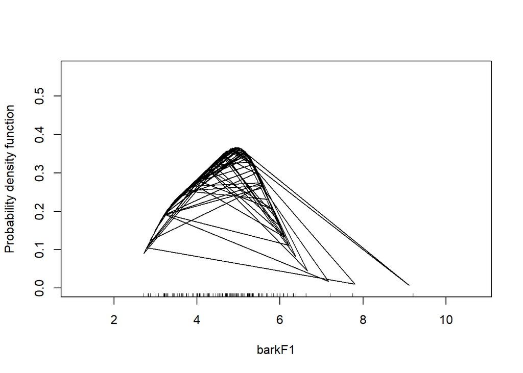

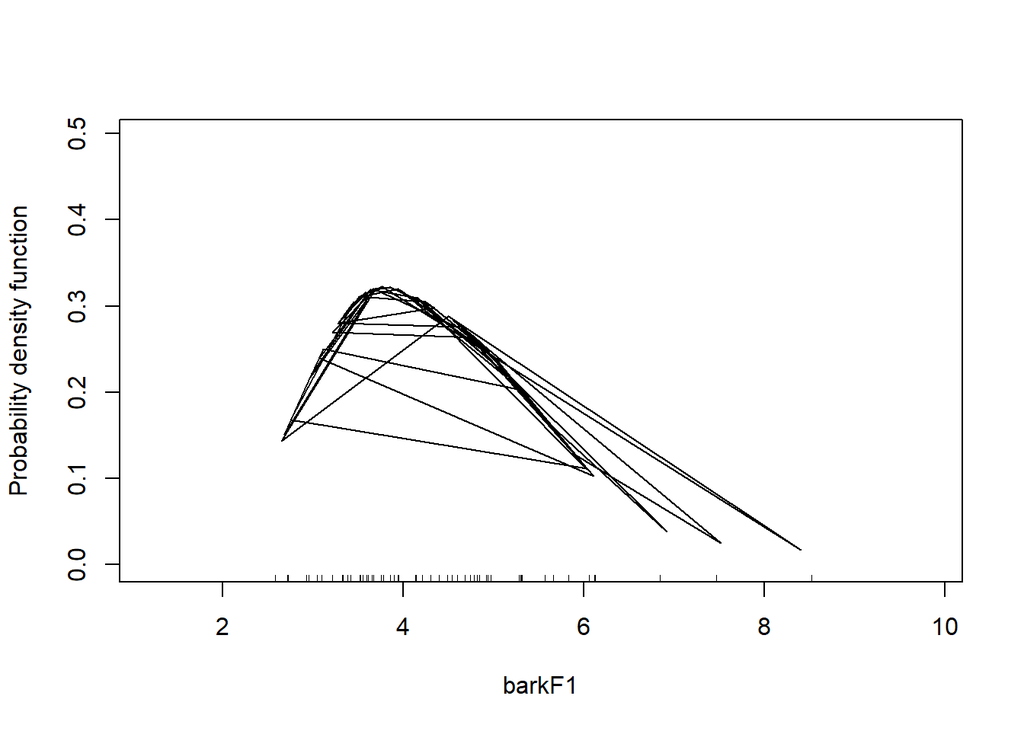

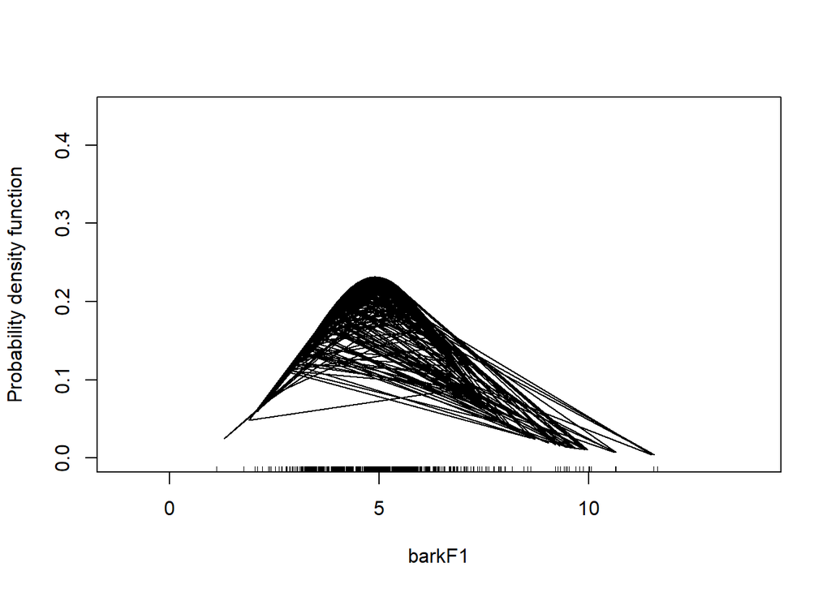

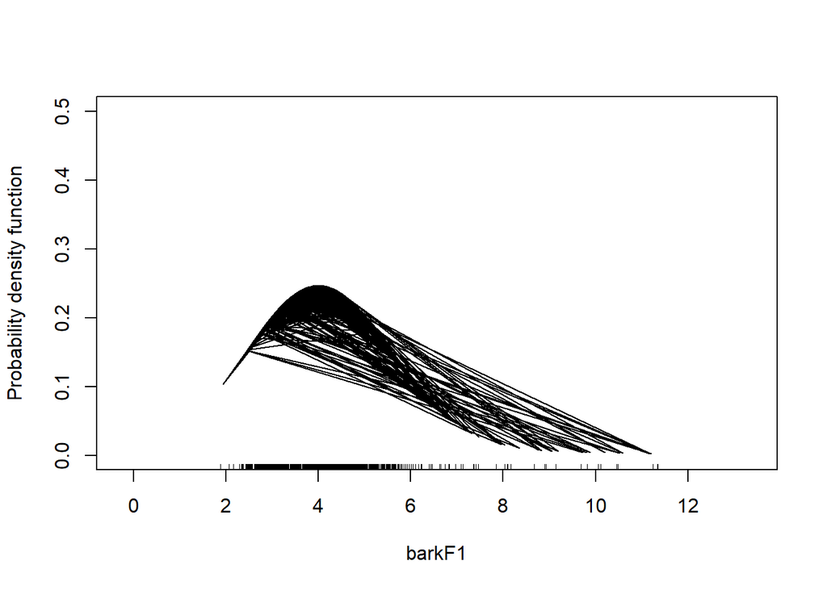

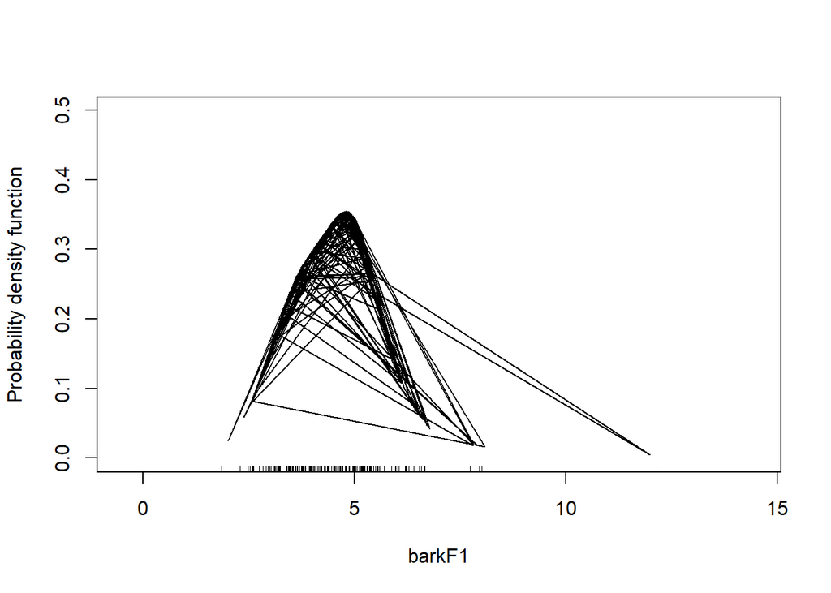

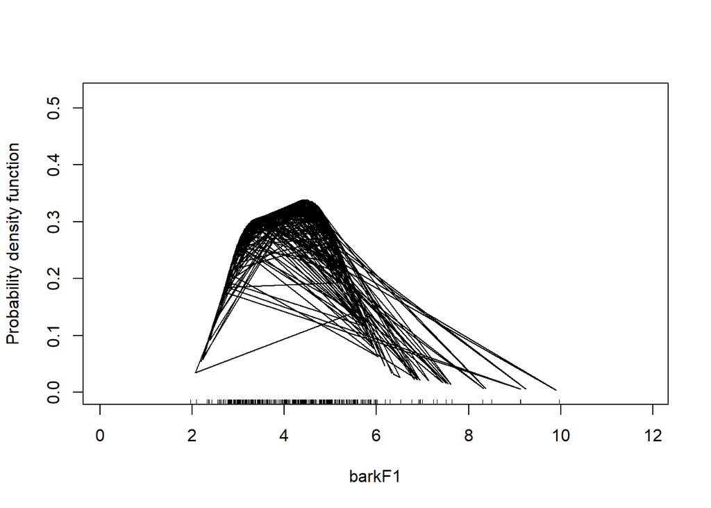

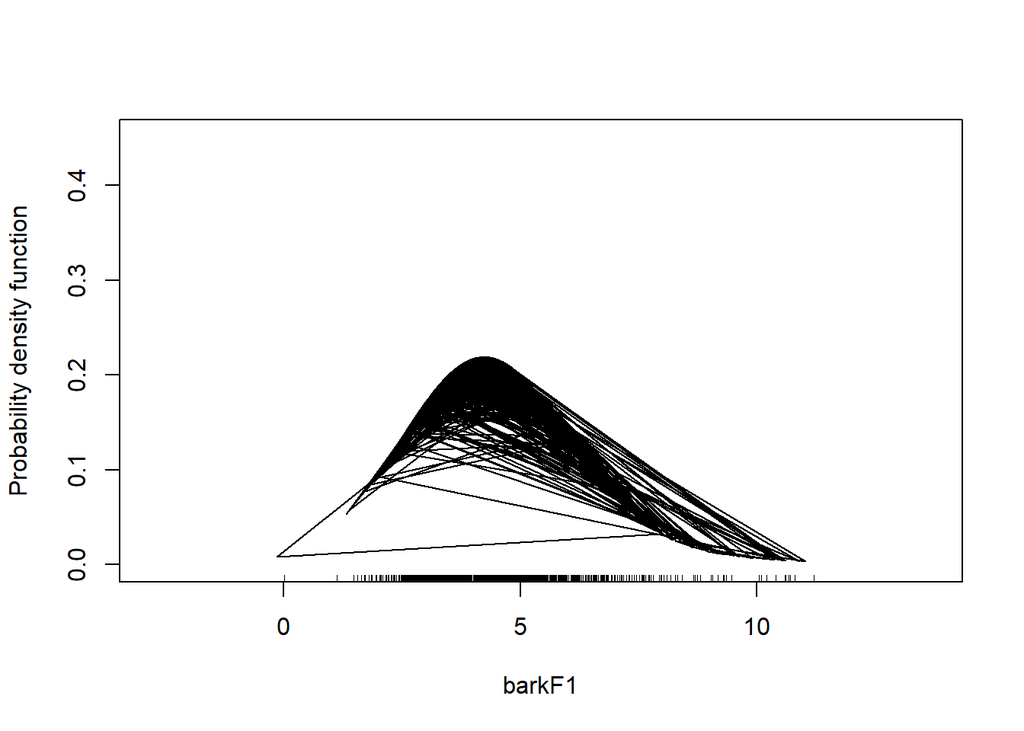

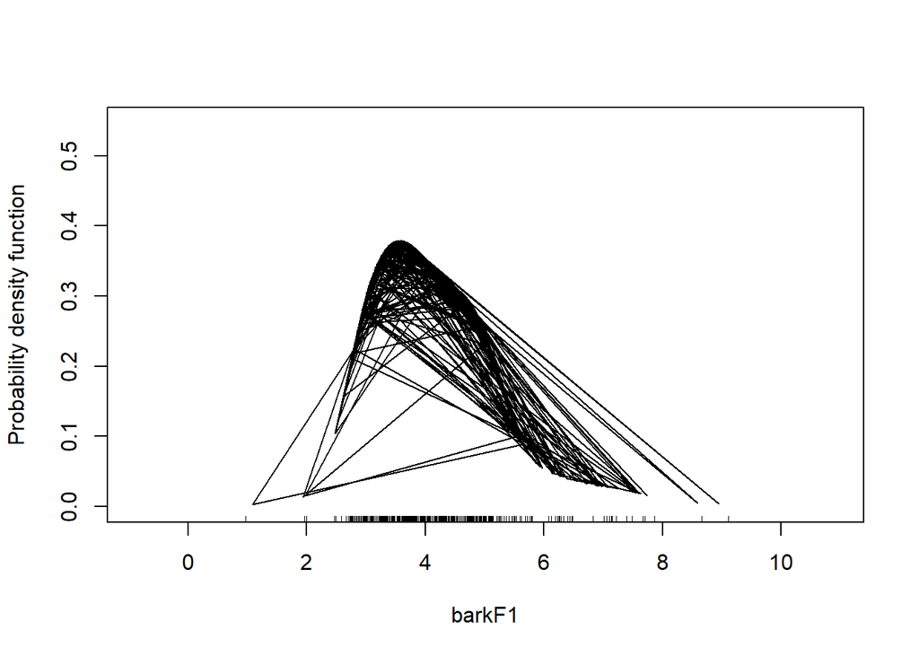

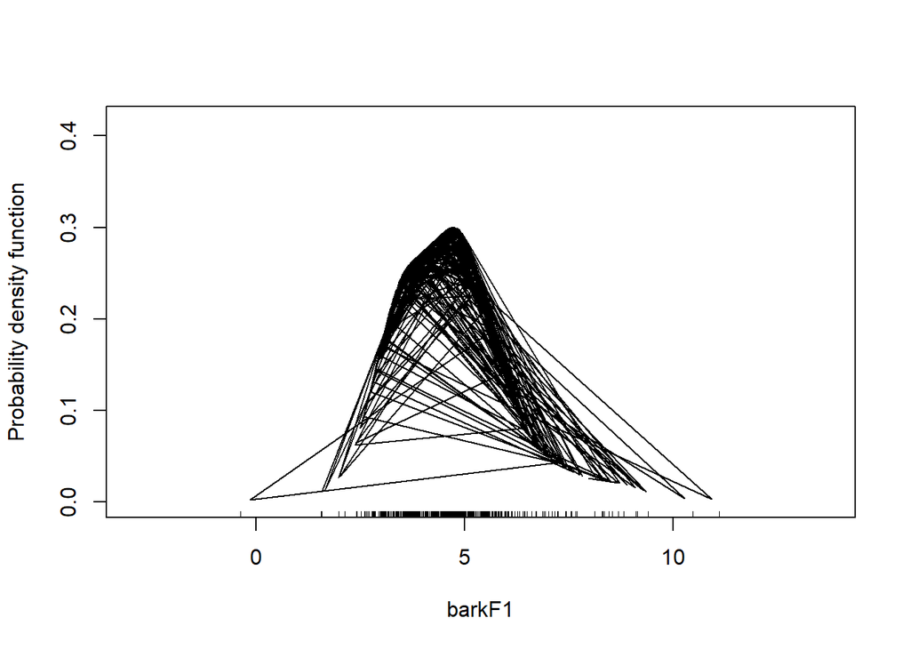

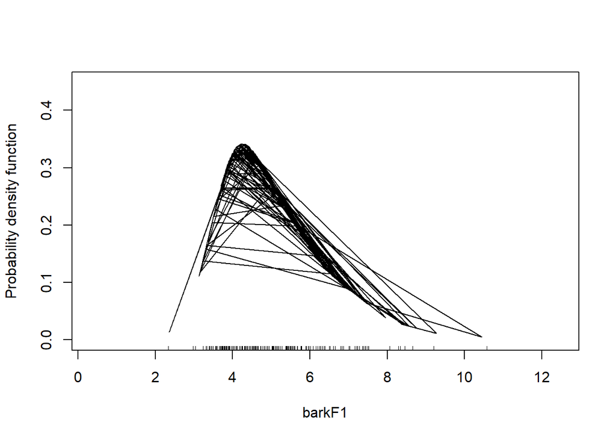

[20 more figures not shown]

```r
# inspect
nrow(fdat); head(fdat); summary(fdat$densF1)
```

```
## [1] 7547
```

```
## # A tibble: 6 × 44
## # Groups:   type, tvariety, label [3]
##   id     tmin  tmax label word  file      midpoint    F1    F2    F3 vowel type
##   <chr> <dbl> <dbl> <chr> <chr> <chr>        <dbl> <dbl> <dbl> <dbl> <chr> <chr>
## 1 2     16.0  16.0  U     good  SM_ENS_P…     16.0  478. 2264. 2871. ʊ     ENS
## 2 12    13.6  13.7  U     good  SM_ENS_P…     13.6  609. 1093. 2669. ʊ     ENS
## 3 12    36.0  36.1  I     big   SM_ENS_P…     36.0  575. 2155. 2693. ɪ     ENS
## 4 22    24.9  24.9  U     good  SM_ENS_P…     24.9  704. 1901. 2214. ʊ     ENS
## 5 32     1.36  1.44 I     with  SM_ENS_P…      1.4  538. 1799. 2501. ɪ     ENS
## 6 32    18.5  18.5  I     with  SM_ENS_P…     18.5  830. 1641  2242. ɪ     ENS
## # … with 32 more variables: speaker <chr>, tgender <chr>, tformants <chr>,
## #   tvariety <chr>, Code <chr>, Country <chr>, gender <chr>, Age <int>,
## #   Yrs.of.Stay....Yrs. <chr>, ENS.Type <chr>, Major..Occupation <chr>,
## #   Test <chr>, Score <chr>, Listening <chr>, Speaking <chr>,
## #   Pronunciation <chr>, target_f1 <dbl>, target_f2 <dbl>, target_f3 <dbl>,
## #   edist <dbl>, barkF1 <dbl>, barkF2 <dbl>, fspeaker <chr>, lobF1 <dbl[,1]>,
## #   lobF2 <dbl[,1]>, remove <chr>, duration <dbl>, cutoff_duration <dbl>, …
```

```
##          Min.       1st Qu.        Median          Mean       3rd Qu.
## 0.00228003177 0.16933110680 0.20882636462 0.20731504307 0.24470561348
##          Max.
## 0.40215691196
```

```r
fdat <- fdat %>%
  # remove data point within the lowest 25 percent of densities among F1 and F2 values
  # but when label = A: and tvariety is gb
  dplyr::mutate(rmv = ifelse(label == "A:" & tvariety == "gb", "keep", "remove")) %>%
  dplyr::rowwise() %>%
  dplyr::filter(rmv == "keep" | densF1 > qnt1F1 | densF2 > qnt1F2) %>%
  # remove superfluous columns
  dplyr::select(-densF1, -densF2, -qnt1F1, -qnt1F2, -cutoff_duration, -rmv)
# inspect
head(fdat); nrow(fdat)
```

```
## # A tibble: 6 × 39
## # Rowwise:  label, type, tvariety
##   id     tmin  tmax label word  file      midpoint    F1    F2    F3 vowel type
##   <chr> <dbl> <dbl> <chr> <chr> <chr>        <dbl> <dbl> <dbl> <dbl> <chr> <chr>
## 1 2     16.0  16.0  U     good  SM_ENS_P…     16.0  478. 2264. 2871. ʊ     ENS
## 2 12    36.0  36.1  I     big   SM_ENS_P…     36.0  575. 2155. 2693. ɪ     ENS
## 3 22    24.9  24.9  U     good  SM_ENS_P…     24.9  704. 1901. 2214. ʊ     ENS
## 4 32     1.36  1.44 I     with  SM_ENS_P…      1.4  538. 1799. 2501. ɪ     ENS
## 5 32    18.5  18.5  I     with  SM_ENS_P…     18.5  830. 1641  2242. ɪ     ENS
## 6 32    19.4  19.6  I     with  SM_ENS_P…     19.5  548. 1474. 2184. ɪ     ENS
## # … with 27 more variables: speaker <chr>, tgender <chr>, tformants <chr>,
## #   tvariety <chr>, Code <chr>, Country <chr>, gender <chr>, Age <int>,
## #   Yrs.of.Stay....Yrs. <chr>, ENS.Type <chr>, Major..Occupation <chr>,
## #   Test <chr>, Score <chr>, Listening <chr>, Speaking <chr>,
## #   Pronunciation <chr>, target_f1 <dbl>, target_f2 <dbl>, target_f3 <dbl>,
## #   edist <dbl>, barkF1 <dbl>, barkF2 <dbl>, fspeaker <chr>, lobF1 <dbl[,1]>,
## #   lobF2 <dbl[,1]>, remove <chr>, duration <dbl>
```

```
## [1] 7133
```

## 2.7 Remove GB target

```r
fdat <- fdat %>%
  dplyr::filter(tvariety != "gb")
```

## 2.8 Check density

```r
wordplot3 <- function(fdat, vwl1, vwl2){
  plt <- fdat %>%
    dplyr::filter(label == vwl1 | label == vwl2) %>%
    dplyr::group_by(word, label) %>%
    dplyr::mutate(meanF2 = mean(lobF2),
                  meanF1 = mean(lobF1)) %>%
    dplyr::ungroup() %>%
    dplyr::group_by(label) %>%
    dplyr::mutate(cF2 = mean(lobF2),
                  cF1 = mean(lobF1)) %>%
    # plot
    ggplot(aes(x = lobF2, y = lobF1)) +
  stat_density_2d(geom = "polygon",
                  aes(alpha = ..level.., fill = label), bins = 8)  +
    facet_grid( ~ type) +
    scale_x_reverse(position = "top") +
    scale_y_reverse(position = "right") +
    #scale_fill_distiller(palette = "Blues", direction = 1) +
    geom_text(aes(x = meanF2, y = meanF1,
                  label = word, color = label), size = 4) +
    geom_text(aes(x = cF2, y = cF1,
                  label = label), size = 6, color = "gray20") +
    theme_minimal() +
    theme(panel.grid.major = element_blank(),
                  panel.grid.minor = element_blank(),
                  legend.position = "none") +
  scale_color_manual(values = c("orange3", "gray40")) +
  scale_fill_manual(values = c("orange", "gray")) +
    labs(x = "Formant 2 (z-transformed)", y = "Formant 1 (z-transformed)")
  return(plt)
  }
```

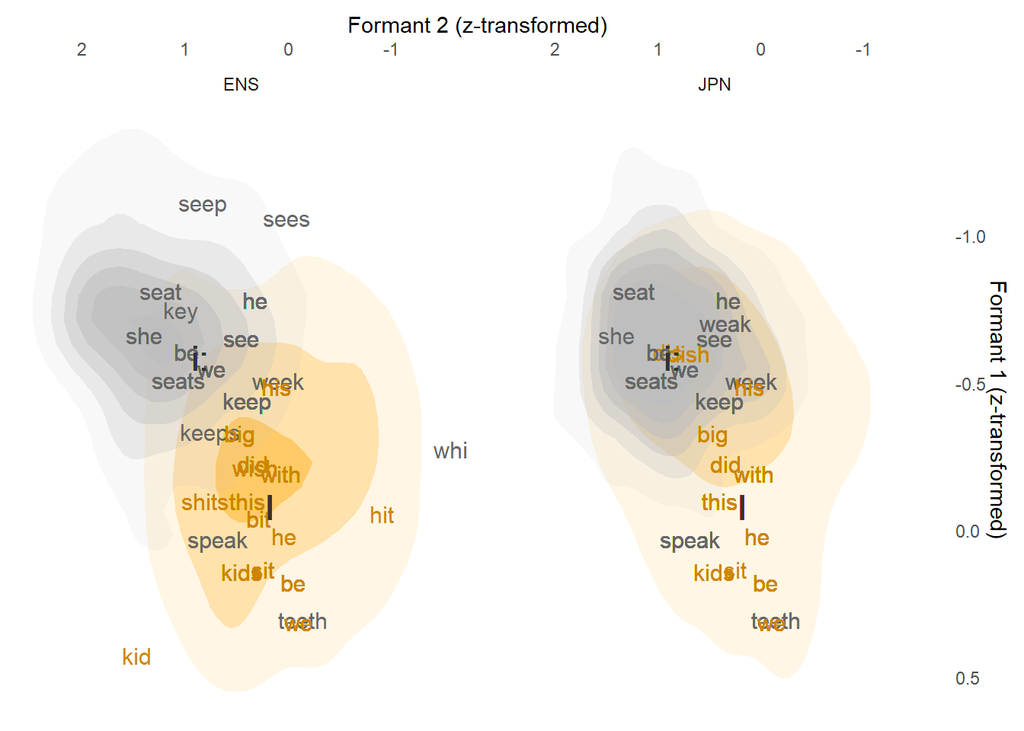

```r
pIi <- wordplot3(fdat = fdat, vwl1 = "I", vwl2 = "i:")
ggsave(here::here("images", "pIi.png"), height = 3,  width = 5, dpi = 320)
pIi
```

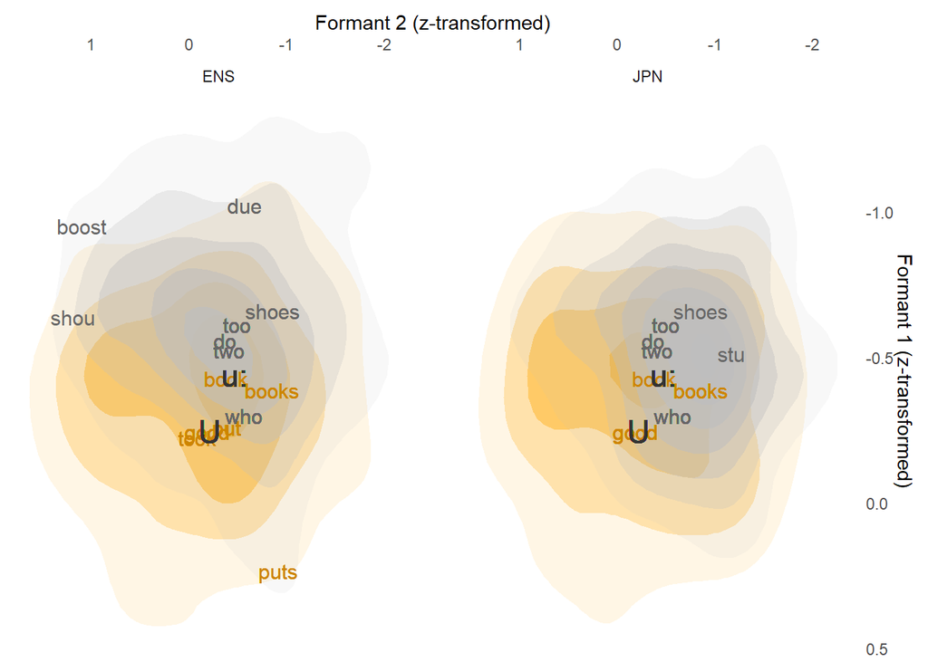

```r
pUu <- wordplot3(fdat = fdat, vwl1 = "U", vwl2 = "u:")
ggsave(here::here("images", "pUu.png"), height = 3,  width = 5, dpi = 320)
pUu
```

## 2.9 Normalization

See [here](https://marissabarlaz.github.io/portfolio/vowelnormalization/)

Gender normalization

```r
# Using mean F3 of open vowels (vowels with F1>600) to approximate female F1&F2 to those of male
tempvowel <- fdat %>%
  dplyr::filter(F1 > 600) %>%
  dplyr::group_by(gender) %>%
  dplyr::mutate(meanF3 = mean(F3))
# extract k: k = ratio of Female F3 to Male F3
k <- max(tempvowel$meanF3) / min(tempvowel$meanF3)
# perform normalization
fdat <- fdat %>%
  dplyr::mutate(barkF1 = phonR::normBark(F1),
                barkF2 = phonR::normBark(F2)) %>%
  dplyr::mutate(normF1 = dplyr::if_else(gender == "f", F1*k, F1),
                normF2 = dplyr::if_else(gender == "f", F2*k, F2))
```

calculate distance from target vowel centroid for each token

```r
tcentroid <- fdat %>%
  dplyr::filter(type == "ENS") %>%
  dplyr::group_by(tvariety, vowel) %>%
  dplyr::summarise(cF1 = median(barkF1),
                   cF2 = median(barkF2))
# inspect
head(tcentroid)
```

```
## # A tibble: 4 × 4
## # Groups:   tvariety [1]
##   tvariety vowel   cF1   cF2
##   <chr>    <chr> <dbl> <dbl>
## 1 us       ɪ      5.05  11.4
## 2 us       iː     4.09  12.7
## 3 us       ʊ      4.54  10.9
## 4 us       uː     4.15  10.7
```

combine

```r
fdat <- dplyr::left_join(fdat, tcentroid) %>%
  # euclidean distance
  dplyr::rowwise() %>%
  dplyr::mutate(ED = sqrt((barkF1-cF1)^2 + (barkF2-cF2)^2)) %>%
  # remove superfluous columns
  dplyr::select(-remove)
# inspect
head(fdat)
```

```
## # A tibble: 6 × 43
## # Rowwise:
##   id     tmin  tmax label word  file      midpoint    F1    F2    F3 vowel type
##   <chr> <dbl> <dbl> <chr> <chr> <chr>        <dbl> <dbl> <dbl> <dbl> <chr> <chr>
## 1 12    36.0  36.1  I     big   SM_ENS_P…    36.0   575. 2155. 2693. ɪ     ENS
## 2 22    24.9  24.9  U     good  SM_ENS_P…    24.9   704. 1901. 2214. ʊ     ENS
## 3 32     1.36  1.44 I     with  SM_ENS_P…     1.4   538. 1799. 2501. ɪ     ENS
## 4 32    18.5  18.5  I     with  SM_ENS_P…    18.5   830. 1641  2242. ɪ     ENS
## 5 32    19.4  19.6  I     with  SM_ENS_P…    19.5   548. 1474. 2184. ɪ     ENS
## 6 52     1.89  1.95 I     with  SM_ENS_P…     1.92  694. 1784. 2378. ɪ     ENS
## # … with 31 more variables: speaker <chr>, tgender <chr>, tformants <chr>,
## #   tvariety <chr>, Code <chr>, Country <chr>, gender <chr>, Age <int>,
## #   Yrs.of.Stay....Yrs. <chr>, ENS.Type <chr>, Major..Occupation <chr>,
## #   Test <chr>, Score <chr>, Listening <chr>, Speaking <chr>,
## #   Pronunciation <chr>, target_f1 <dbl>, target_f2 <dbl>, target_f3 <dbl>,
## #   edist <dbl>, barkF1 <dbl>, barkF2 <dbl>, fspeaker <chr>, lobF1 <dbl[,1]>,
## #   lobF2 <dbl[,1]>, duration <dbl>, normF1 <dbl>, normF2 <dbl>, cF1 <dbl>, …
```

## 2.10 Gramm. Status of Word

```r
gram <- c("be", "but", "did", "do", "get", "gets", "got", "had", "has", "he", "his",
          "she", "that", "this", "too", "was", "we", "what", "who", "with")
fdat <- fdat %>%
  # gramm. category of word
  dplyr::mutate(WordType = ifelse(word %in% gram, "grammatical", "lexical"))
```

## 2.11 Overview of the data

```r
tb1 <- fdat %>%
  dplyr::ungroup() %>%
  dplyr::filter(label == "I" | label == "i:" | label == "U" | label == "u:" ) %>%
  dplyr::group_by(type, label) %>%
  dplyr::summarise(speakers = max(length(table(speaker))),
                   obs = n()) %>%
  dplyr::mutate(speakers = max(speakers)) %>%
  tidyr::spread(label, obs) %>%
  dplyr::ungroup() %>%
  dplyr::add_row(type = "Total",
                 speakers = sum(.$speakers),
                 I = sum(.$I),
                 `i:` = sum(.$`i:`),
                 U = sum(.$U),
                 `u:` = sum(.$`u:`))
# save
write.table(tb1, here::here("tables", "tb1.txt"), sep = "\t")
# inspect
tb1
```

[output not shown]

## 2.12 Save data to disc

```r
# save
base::saveRDS(fdat, file = here::here("data", "fdat_kiel.rda"))
# inspect
nrow(fdat); head(fdat)
```

```
## [1] 4342
```

```
## # A tibble: 6 × 44
## # Rowwise:
##   id     tmin  tmax label word  file      midpoint    F1    F2    F3 vowel type
##   <chr> <dbl> <dbl> <chr> <chr> <chr>        <dbl> <dbl> <dbl> <dbl> <chr> <chr>
## 1 12    36.0  36.1  I     big   SM_ENS_P…    36.0   575. 2155. 2693. ɪ     ENS
## 2 22    24.9  24.9  U     good  SM_ENS_P…    24.9   704. 1901. 2214. ʊ     ENS
## 3 32     1.36  1.44 I     with  SM_ENS_P…     1.4   538. 1799. 2501. ɪ     ENS
## 4 32    18.5  18.5  I     with  SM_ENS_P…    18.5   830. 1641  2242. ɪ     ENS
## 5 32    19.4  19.6  I     with  SM_ENS_P…    19.5   548. 1474. 2184. ɪ     ENS
## 6 52     1.89  1.95 I     with  SM_ENS_P…     1.92  694. 1784. 2378. ɪ     ENS
## # … with 32 more variables: speaker <chr>, tgender <chr>, tformants <chr>,
## #   tvariety <chr>, Code <chr>, Country <chr>, gender <chr>, Age <int>,
## #   Yrs.of.Stay....Yrs. <chr>, ENS.Type <chr>, Major..Occupation <chr>,
## #   Test <chr>, Score <chr>, Listening <chr>, Speaking <chr>,
## #   Pronunciation <chr>, target_f1 <dbl>, target_f2 <dbl>, target_f3 <dbl>,
## #   edist <dbl>, barkF1 <dbl>, barkF2 <dbl>, fspeaker <chr>, lobF1 <dbl[,1]>,
## #   lobF2 <dbl[,1]>, duration <dbl>, normF1 <dbl>, normF2 <dbl>, cF1 <dbl>, …
```

# 3 Statistical Analysis

## 3.1 Bhattacharyya’s affinity

function for extracting Bhattacharyya’s affinity by type and target variety

```r
exba <- function(data, section, target, vwl1, vwl2){
  ba <- data %>%
  ungroup() %>%
  dplyr::filter(type == section,
                tvariety == target,
                label == vwl1 | label == vwl2)

  ba_formants <- ba %>%  dplyr::select(lobF1, lobF2)
  # extract vowels
  ba_vowel <- ba %>%  dplyr::select(vowel)
  # spatial data frame
  ba_spdf <- SpatialPointsDataFrame(ba_formants, ba_vowel)
  # calculate Bhattacharyya's affinity
  ba_ba <- kerneloverlap(ba_spdf, method = "BA")
  # result
  return(ba_ba[1,2])
}
```

### I vs i:

```r
# JPN
exba(data = fdat, section = "JPN", target = "us", vwl1 = "I", vwl2 = "i:")
```

```
## [1] 0.90072890635
```

```r
# ENS
exba(data = fdat, section = "ENS", target = "us", vwl1 = "I", vwl2 = "i:")
```

```
## [1] 0.757321187732
```

### U vs u:

High-back

```r
# JPN
exba(data = fdat, section = "JPN", target = "us", vwl1 = "U", vwl2 = "u:")
```

```
## [1] 0.932405695532
```

```r
# ENS
exba(data = fdat, section = "ENS", target = "us", vwl1 = "U", vwl2 = "u:")
```

```
## [1] 0.952328623076
```

## 3.2 Mixed-Effects Model (DV:Duration)

check data

```r
durtb <- fdat %>%
  dplyr::group_by(type, tvariety, vowel) %>%
  dplyr::summarise(duration_mean = round(mean(duration), 3),
                   duration_sd = round(sd(duration), 3),
                   freq = n())
# inspect
durtb
```

```
## # A tibble: 8 × 6
## # Groups:   type, tvariety [2]
##   type  tvariety vowel duration_mean duration_sd  freq
##   <chr> <chr>    <chr>         <dbl>       <dbl> <int>
## 1 ENS   us       ɪ             0.067       0.037   693
## 2 ENS   us       iː            0.079       0.035   939
## 3 ENS   us       ʊ             0.06        0.032   189
## 4 ENS   us       uː            0.095       0.05    395
## 5 JPN   us       ɪ             0.083       0.059  1122
## 6 JPN   us       iː            0.112       0.064   535
## 7 JPN   us       ʊ             0.089       0.064   188
## 8 JPN   us       uː            0.131       0.09    281
```

```r
durtb %>%
  dplyr::mutate(mean_sd = paste0(duration_mean, " (", duration_sd, ", N = ", freq, ")")) %>%
  dplyr::select(-duration_mean, -duration_sd, -freq) %>%
  tidyr::spread(type, mean_sd) %>%
  flextable::flextable()
```

| tvariety | vowel | ENS | JPN |
| --- | --- | --- | --- |
| us | ɪ | 0.067 (0.037, N = 693) | 0.083 (0.059, N = 1122) |
| us | iː | 0.079 (0.035, N = 939) | 0.112 (0.064, N = 535) |
| us | ʊ | 0.06 (0.032, N = 189) | 0.089 (0.064, N = 188) |
| us | uː | 0.095 (0.05, N = 395) | 0.131 (0.09, N = 281) |

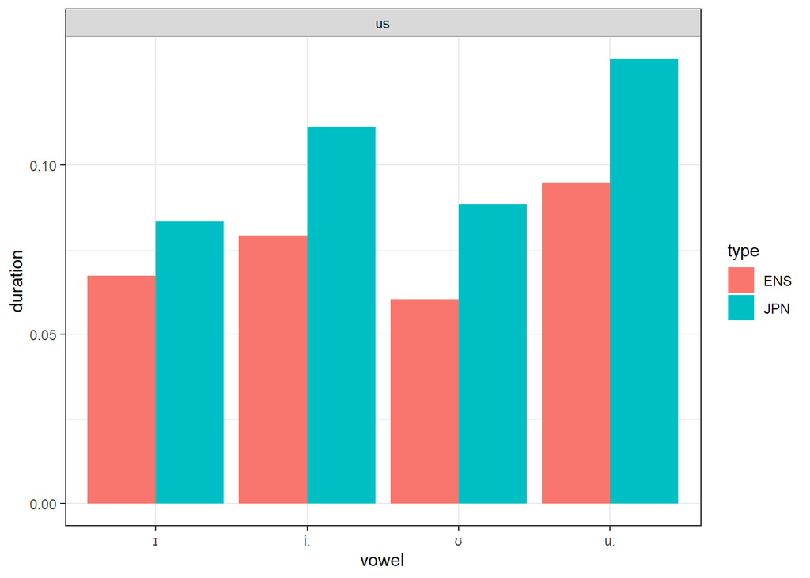

```r
fdat %>%
  dplyr::group_by(type, tvariety, vowel) %>%
  dplyr::summarise(duration = mean(duration)) %>%
  ggplot(aes(x = vowel, y = duration, fill = type)) +
  geom_bar(stat = "identity", position=position_dodge()) +
  facet_grid( ~ tvariety) +
  theme_bw()
```

```r
diff_dat <- fdat %>%
  dplyr::group_by(type, tvariety, label) %>%
  dplyr::summarise(dur = mean(duration)) %>%
  dplyr::filter(label == "I" |
                  label == "i:" |
                  label == "U" |
                  label == "u:") %>%
  tidyr::spread(label, dur) %>%
  dplyr::mutate(diff_i = `i:` - I,
                diff_u = `u:` - U) %>%
  dplyr::select(-I, -U, -`i:`, -`u:`) %>%
  tidyr::gather(pair, diff, diff_i:diff_u) %>%
  dplyr::mutate(pair = dplyr::case_when(pair == "diff_i" ~ "Ii",
                                        pair == "diff_u" ~ "Uu"))
# inspect
diff_dat
```

```
## # A tibble: 4 × 4
## # Groups:   type, tvariety [2]
##   type  tvariety pair    diff
##   <chr> <chr>    <chr>  <dbl>
## 1 ENS   us       Ii    0.0120
## 2 JPN   us       Ii    0.0281
## 3 ENS   us       Uu    0.0345
## 4 JPN   us       Uu    0.0430
```

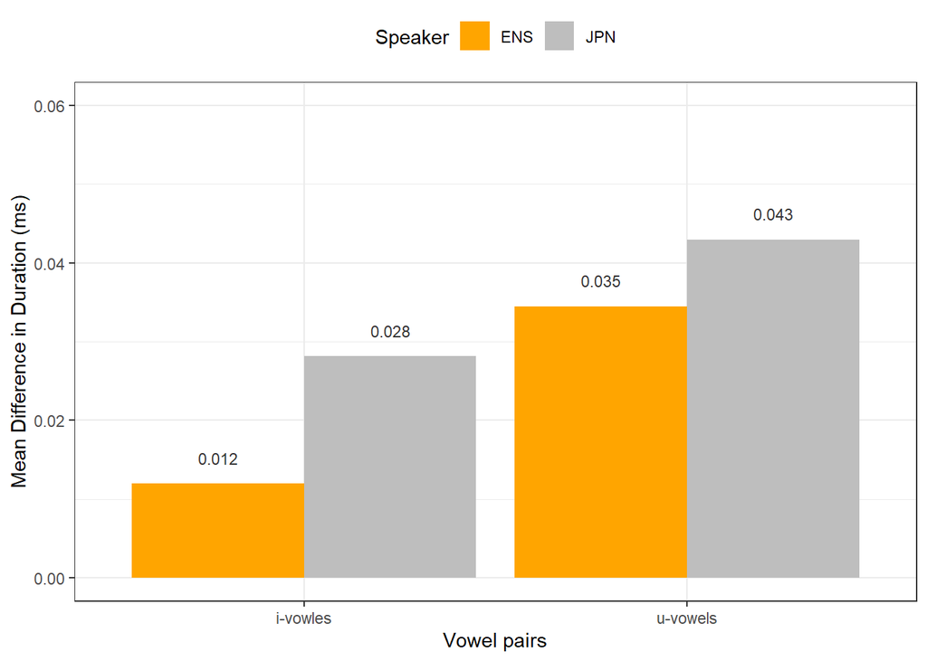

```r
dplot <- diff_dat %>%
  dplyr::rename(Speaker = type) %>%
  dplyr::mutate(pair = ifelse(pair == "Ii", "i-vowles", "u-vowels")) %>%
  ggplot(aes(x = pair, y = diff, fill = Speaker)) +
  geom_bar(stat = "identity", position = position_dodge()) +
    # define colors
  scale_fill_manual(values= c("orange", "gray")) +
  # add text and define colour
  geom_text(aes(label=round(diff, 3)), vjust=-1.6, color="gray20",
            # define text position and size
            position = position_dodge(0.9),  size=3) +
  theme_bw() +
  coord_cartesian(ylim = c(0, .06)) +
  labs(x = "Vowel pairs", y = "Mean Difference in Duration (ms)") +
  theme(legend.position = "top")
# save
ggsave(here::here("images", "dplot.png"), height = 3,  width = 5, dpi = 320)
# inspect
dplot
```

### 3.2.1 Model Fitting

base-line model

```r
m0 <- lmer(duration ~ 1 + (1 | speaker) + (1 | word), data = fdat)
# inspect
summary(m0)
```

```
## Linear mixed model fit by REML ['lmerMod']
## Formula: duration ~ 1 + (1 | speaker) + (1 | word)
##    Data: fdat
##
## REML criterion at convergence: -12931.7
##
## Scaled residuals:
##          Min           1Q       Median           3Q          Max
## -1.865275504 -0.703720476 -0.265594907  0.500345507  5.266645671
##
## Random effects:
##  Groups   Name        Variance       Std.Dev.
##  speaker  (Intercept) 0.000211080083 0.0145285953
##  word     (Intercept) 0.000249471561 0.0157946687
##  Residual             0.002832604480 0.0532222179
## Number of obs: 4342, groups:  speaker, 149; word, 46
##
## Fixed effects:
##                  Estimate    Std. Error  t value
## (Intercept) 0.09124291165 0.00371118364 24.58593
```

**Main effects**

#### type

sig.

```r
# add type
m1 <- update(m0, . ~ . + type)
# inspect
sjPlot::tab_model(m1)
```

|  | duration |  |  |
| --- | --- | --- | --- |
| Predictors | Estimates | CI | p |
| (Intercept) | 0.08 | 0.07 – 0.09 | **<0.001** |
| type [JPN] | 0.02 | 0.02 – 0.03 | **<0.001** |
| Random Effects |  |  |  |
| σ<sup>2</sup> | 0.00 |  |  |
| τ<sub>00</sub> <sub>speaker</sub> | 0.00 |  |  |
| τ<sub>00</sub> <sub>word</sub> | 0.00 |  |  |
| ICC | 0.13 |  |  |
| N <sub>speaker</sub> | 149 |  |  |
| N <sub>word</sub> | 46 |  |  |
| Observations | 4342 |  |  |
| Marginal R<sup>2</sup> / Conditional R<sup>2</sup> | 0.040 / 0.164 |  |  |

#### vowel (vowel)

sig.

```r
# add vowel
m2 <- update(m1, . ~ . + vowel)
# checks
anova(m1, m2, test = "Chi")
```

```
## Data: fdat
## Models:
## m1: duration ~ (1 | speaker) + (1 | word) + type
## m2: duration ~ (1 | speaker) + (1 | word) + type + vowel
##    npar          AIC          BIC      logLik     deviance    Chisq Df
## m1    5 -13067.84723 -13035.96678 6538.923616 -13077.84723
## m2    8 -13161.50529 -13110.49657 6588.752646 -13177.50529 99.65806  3
##                Pr(>Chisq)
## m1
## m2 < 0.000000000000000222 ***
## ---
## Signif. codes:  0 '***' 0.001 '**' 0.01 '*' 0.05 '.' 0.1 ' ' 1
```

```r
car::vif(m2)
```

```
##                GVIF Df GVIF^(1/(2*Df))
## type  1.00348190896  1   1.00173944165
## vowel 1.00348190896  3   1.00057947802
```

```r
# inspect
sjPlot::tab_model(m2)
```

|  | duration |  |  |
| --- | --- | --- | --- |
| Predictors | Estimates | CI | p |
| (Intercept) | 0.06 | 0.06 – 0.07 | **<0.001** |
| type [JPN] | 0.02 | 0.02 – 0.03 | **<0.001** |
| vowel [iː] | 0.03 | 0.02 – 0.03 | **<0.001** |
| vowel [ʊ] | 0.01 | -0.01 – 0.02 | 0.424 |
| vowel [uː] | 0.04 | 0.03 – 0.06 | **<0.001** |
| Random Effects |  |  |  |
| σ<sup>2</sup> | 0.00 |  |  |
| τ<sub>00</sub> <sub>speaker</sub> | 0.00 |  |  |
| τ<sub>00</sub> <sub>word</sub> | 0.00 |  |  |
| ICC | 0.08 |  |  |
| N <sub>speaker</sub> | 149 |  |  |
| N <sub>word</sub> | 46 |  |  |
| Observations | 4342 |  |  |
| Marginal R<sup>2</sup> / Conditional R<sup>2</sup> | 0.103 / 0.174 |  |  |

#### gender

not sig.

```r
# add gender
m3 <- update(m2, . ~ . + gender)
# checks
anova(m2, m3, test = "Chi")
```

```
## Data: fdat
## Models:
## m2: duration ~ (1 | speaker) + (1 | word) + type + vowel
## m3: duration ~ (1 | speaker) + (1 | word) + type + vowel + gender
##    npar          AIC          BIC      logLik     deviance   Chisq Df
## m2    8 -13161.50529 -13110.49657 6588.752646 -13177.50529
## m3    9 -13159.95488 -13102.57006 6588.977439 -13177.95488 0.44959  1
##    Pr(>Chisq)
## m2
## m3    0.50253
```

```r
car::vif(m3)
```

```
##                 GVIF Df GVIF^(1/(2*Df))
## type   1.01144370960  1   1.00570557799
## vowel  1.00573831311  3   1.00095410682
## gender 1.00983800167  1   1.00490696170
```

```r
# inspect
sjPlot::tab_model(m3)
```

|  | duration |  |  |
| --- | --- | --- | --- |
| Predictors | Estimates | CI | p |
| (Intercept) | 0.06 | 0.05 – 0.07 | **<0.001** |
| type [JPN] | 0.02 | 0.02 – 0.03 | **<0.001** |
| vowel [iː] | 0.03 | 0.02 – 0.03 | **<0.001** |
| vowel [ʊ] | 0.01 | -0.01 – 0.02 | 0.414 |
| vowel [uː] | 0.04 | 0.03 – 0.06 | **<0.001** |
| gender [m] | 0.00 | -0.00 – 0.01 | 0.498 |
| Random Effects |  |  |  |
| σ<sup>2</sup> | 0.00 |  |  |
| τ<sub>00</sub> <sub>speaker</sub> | 0.00 |  |  |
| τ<sub>00</sub> <sub>word</sub> | 0.00 |  |  |
| ICC | 0.08 |  |  |
| N <sub>speaker</sub> | 149 |  |  |
| N <sub>word</sub> | 46 |  |  |
| Observations | 4342 |  |  |
| Marginal R<sup>2</sup> / Conditional R<sup>2</sup> | 0.103 / 0.174 |  |  |

#### Age

not sig.

```r
# add Age
m4 <- update(m2, . ~ . + Age)
# checks
anova(m2, m4, test = "Chi")
```

```
## Data: fdat
## Models:
## m2: duration ~ (1 | speaker) + (1 | word) + type + vowel
## m4: duration ~ (1 | speaker) + (1 | word) + type + vowel + Age
##    npar          AIC          BIC      logLik     deviance   Chisq Df
## m2    8 -13161.50529 -13110.49657 6588.752646 -13177.50529
## m4    9 -13159.50849 -13102.12367 6588.754243 -13177.50849 0.00319  1
##    Pr(>Chisq)
## m2
## m4    0.95494
```

```r
car::vif(m4)
```

```
##                GVIF Df GVIF^(1/(2*Df))
## type  1.57503457028  1   1.25500381285
## vowel 1.00518473461  3   1.00086226156
## Age   1.57010227628  1   1.25303722063
```

```r
# inspect
sjPlot::tab_model(m4)
```

|  | duration |  |  |
| --- | --- | --- | --- |
| Predictors | Estimates | CI | p |
| (Intercept) | 0.06 | 0.05 – 0.07 | **<0.001** |
| type [JPN] | 0.02 | 0.02 – 0.03 | **<0.001** |
| vowel [iː] | 0.03 | 0.02 – 0.03 | **<0.001** |
| vowel [ʊ] | 0.01 | -0.01 – 0.02 | 0.424 |
| vowel [uː] | 0.04 | 0.03 – 0.06 | **<0.001** |
| Age | 0.00 | -0.00 – 0.00 | 0.950 |
| Random Effects |  |  |  |
| σ<sup>2</sup> | 0.00 |  |  |
| τ<sub>00</sub> <sub>speaker</sub> | 0.00 |  |  |
| τ<sub>00</sub> <sub>word</sub> | 0.00 |  |  |
| ICC | 0.08 |  |  |
| N <sub>speaker</sub> | 149 |  |  |
| N <sub>word</sub> | 46 |  |  |
| Observations | 4342 |  |  |
| Marginal R<sup>2</sup> / Conditional R<sup>2</sup> | 0.103 / 0.174 |  |  |

#### WordType

not sig.

```r
# add WordType
m5 <- update(m2, . ~ . + WordType)
# checks
anova(m2, m5, test = "Chi")
```

```
## Data: fdat
## Models:
## m2: duration ~ (1 | speaker) + (1 | word) + type + vowel
## m5: duration ~ (1 | speaker) + (1 | word) + type + vowel + WordType
##    npar          AIC          BIC      logLik     deviance   Chisq Df
## m2    8 -13161.50529 -13110.49657 6588.752646 -13177.50529
## m5    9 -13159.51041 -13102.12560 6588.755205 -13177.51041 0.00512  1
##    Pr(>Chisq)
## m2
## m5    0.94298
```

```r
car::vif(m5)
```

```
##                   GVIF Df GVIF^(1/(2*Df))
## type     1.00523552704  1   1.00261434612
## vowel    1.23081269930  3   1.03521842910
## WordType 1.22938071778  1   1.10877442150
```

```r
# inspect
sjPlot::tab_model(m5)
```

|  | duration |  |  |
| --- | --- | --- | --- |
| Predictors | Estimates | CI | p |
| (Intercept) | 0.06 | 0.05 – 0.07 | **<0.001** |
| type [JPN] | 0.02 | 0.02 – 0.03 | **<0.001** |
| vowel [iː] | 0.03 | 0.02 – 0.03 | **<0.001** |
| vowel [ʊ] | 0.01 | -0.01 – 0.02 | 0.444 |
| vowel [uː] | 0.05 | 0.03 – 0.06 | **<0.001** |
| WordType [lexical] | -0.00 | -0.01 – 0.01 | 0.972 |
| Random Effects |  |  |  |
| σ<sup>2</sup> | 0.00 |  |  |
| τ<sub>00</sub> <sub>speaker</sub> | 0.00 |  |  |
| τ<sub>00</sub> <sub>word</sub> | 0.00 |  |  |
| ICC | 0.08 |  |  |
| N <sub>speaker</sub> | 149 |  |  |
| N <sub>word</sub> | 46 |  |  |
| Observations | 4342 |  |  |
| Marginal R<sup>2</sup> / Conditional R<sup>2</sup> | 0.104 / 0.177 |  |  |

**Interactions**

#### type x vowel

sig.

```r
# add type x vowel
m6 <- update(m2, . ~ . + type * vowel)
# checks
anova(m2, m6, test = "Chi")
```

```
## Data: fdat
## Models:
## m2: duration ~ (1 | speaker) + (1 | word) + type + vowel
## m6: duration ~ (1 | speaker) + (1 | word) + type + vowel + type:vowel
##    npar          AIC          BIC      logLik     deviance   Chisq Df
## m2    8 -13161.50529 -13110.49657 6588.752646 -13177.50529
## m6   11 -13181.44809 -13111.31110 6601.724046 -13203.44809 25.9428  3
##      Pr(>Chisq)
## m2
## m6 0.0000098041 ***
## ---
## Signif. codes:  0 '***' 0.001 '**' 0.01 '*' 0.05 '.' 0.1 ' ' 1
```

```r
car::vif(m6)
```

```
##                     GVIF Df GVIF^(1/(2*Df))
## type       2.02583290836  1   1.42331757116
## vowel      1.95697629884  3   1.11840112257
## type:vowel 3.32906059287  3   1.22195050908
```

```r
# inspect
sjPlot::tab_model(m6)
```

|  | duration |  |  |
| --- | --- | --- | --- |
| Predictors | Estimates | CI | p |
| (Intercept) | 0.07 | 0.06 – 0.07 | **<0.001** |
| type [JPN] | 0.01 | 0.01 – 0.02 | **<0.001** |
| vowel [iː] | 0.02 | 0.01 – 0.02 | **<0.001** |
| vowel [ʊ] | -0.00 | -0.02 – 0.01 | 0.902 |
| vowel [uː] | 0.03 | 0.02 – 0.05 | **<0.001** |
| type [JPN] * vowel [iː] | 0.02 | 0.01 – 0.02 | **<0.001** |
| type [JPN] * vowel [ʊ] | 0.01 | 0.00 – 0.02 | **0.037** |
| type [JPN] * vowel [uː] | 0.02 | 0.01 – 0.03 | **<0.001** |
| Random Effects |  |  |  |
| σ<sup>2</sup> | 0.00 |  |  |
| τ<sub>00</sub> <sub>speaker</sub> | 0.00 |  |  |
| τ<sub>00</sub> <sub>word</sub> | 0.00 |  |  |
| ICC | 0.07 |  |  |
| N <sub>speaker</sub> | 149 |  |  |
| N <sub>word</sub> | 46 |  |  |
| Observations | 4342 |  |  |
| Marginal R<sup>2</sup> / Conditional R<sup>2</sup> | 0.109 / 0.175 |  |  |

#### type x Age

unacc. vifs

```r
# add type x Age
m7 <- update(m6, . ~ . + type * Age)
# checks
car::vif(m7)
```

```
##                      GVIF Df GVIF^(1/(2*Df))
## type       28.46538962369  1   5.33529658254
## vowel       1.96901572934  3   1.11954493871
## Age         1.68517426620  1   1.29814262167
## type:vowel  3.34990960009  3   1.22322265115
## type:Age   24.83785729417  1   4.98375935356
```

#### type x gender

```r
# add type x gender
m8 <- update(m6, . ~ . + type * gender)
# checks
car::vif(m8)
```

```
##                      GVIF Df GVIF^(1/(2*Df))
## type        4.05301425504  1   2.01320993814
## vowel       2.01028823740  3   1.12342233843
## gender      2.08186082259  1   1.44286549012
## type:vowel  3.42560470206  3   1.22778655800
## type:gender 3.67190333491  1   1.91622110804
```

#### type x WordType

unacc. vifs

```r
# add type x gender
m9 <- update(m6, . ~ . + type * WordType)
# checks
car::vif(m9)
```

```
##                        GVIF Df GVIF^(1/(2*Df))
## type          2.06607814024  1   1.43738587033
## vowel         2.52538244117  3   1.16695612032
## WordType      1.57903732774  1   1.25659752019
## type:vowel    7.88235613571  3   1.41072601604
## type:WordType 3.23141173365  1   1.79761278746
```

sig.

```r
# add type x gender
m10 <- update(m6, . ~ . + type * gender)
# checks
car::vif(m10)
```

```
##                      GVIF Df GVIF^(1/(2*Df))
## type        4.05301425504  1   2.01320993814
## vowel       2.01028823740  3   1.12342233843
## gender      2.08186082259  1   1.44286549012
## type:vowel  3.42560470206  3   1.22778655800
## type:gender 3.67190333491  1   1.91622110804
```

```r
anova(m6, m10, test = "Chi")
```

```
## Data: fdat
## Models:
## m6: duration ~ (1 | speaker) + (1 | word) + type + vowel + type:vowel
## m10: duration ~ (1 | speaker) + (1 | word) + type + vowel + gender + type:vowel + type:gender
##     npar          AIC          BIC      logLik     deviance    Chisq Df
## m6    11 -13181.44809 -13111.31110 6601.724046 -13203.44809
## m10   13 -13195.90273 -13113.01355 6610.951363 -13221.90273 18.45463  2
##      Pr(>Chisq)
## m6
## m10 0.000098317 ***
## ---
## Signif. codes:  0 '***' 0.001 '**' 0.01 '*' 0.05 '.' 0.1 ' ' 1
```

```r
# inspect
sjPlot::tab_model(m10)
```

|  | duration |  |  |
| --- | --- | --- | --- |
| Predictors | Estimates | CI | p |
| (Intercept) | 0.06 | 0.05 – 0.07 | **<0.001** |
| type [JPN] | 0.03 | 0.02 – 0.03 | **<0.001** |
| vowel [iː] | 0.02 | 0.01 – 0.02 | **<0.001** |
| vowel [ʊ] | 0.00 | -0.01 – 0.01 | 0.981 |
| vowel [uː] | 0.03 | 0.02 – 0.05 | **<0.001** |
| gender [m] | 0.01 | 0.00 – 0.02 | **0.001** |
| type [JPN] * vowel [iː] | 0.01 | 0.01 – 0.02 | **0.001** |
| type [JPN] * vowel [ʊ] | 0.01 | -0.00 – 0.02 | 0.056 |
| type [JPN] * vowel [uː] | 0.02 | 0.01 – 0.03 | **<0.001** |
| type [JPN] * gender [m] | -0.02 | -0.03 – -0.01 | **<0.001** |
| Random Effects |  |  |  |
| σ<sup>2</sup> | 0.00 |  |  |
| τ<sub>00</sub> <sub>speaker</sub> | 0.00 |  |  |
| τ<sub>00</sub> <sub>word</sub> | 0.00 |  |  |
| ICC | 0.07 |  |  |
| N <sub>speaker</sub> | 149 |  |  |
| N <sub>word</sub> | 46 |  |  |
| Observations | 4342 |  |  |
| Marginal R<sup>2</sup> / Conditional R<sup>2</sup> | 0.115 / 0.178 |  |  |

unacc. vifs

```r
# add type x gender
m11 <- update(m10, . ~ . + type * Age)
# checks
car::vif(m11)
```

```
##                       GVIF Df GVIF^(1/(2*Df))
## type        28.94738834600  1   5.38027772016
## vowel        2.02244786248  3   1.12455203489
## gender       2.13028772385  1   1.45955052117
## Age          1.72016827587  1   1.31155185787
## type:vowel   3.44440157021  3   1.22890684455
## type:gender  3.75516800179  1   1.93782558601
## type:Age    25.18979919131  1   5.01894403150
```

unacc. vifs

```r
# add type x gender
m12 <- update(m10, . ~ . + type * WordType)
# checks
car::vif(m12)
```

```
##                        GVIF Df GVIF^(1/(2*Df))
## type          4.07904034576  1   2.01966342388
## vowel         2.59698234349  3   1.17240636121
## gender        2.08337438886  1   1.44338989496
## WordType      1.60213058655  1   1.26575297217
## type:vowel    8.05554294367  3   1.41584529801
## type:gender   3.67270790611  1   1.91643103349
## type:WordType 3.24695995343  1   1.80193228325
```

#### gender x Age

unacc. vifs

```r
# add type x gender
m13 <- update(m10, . ~ . + gender * Age)
# checks
car::vif(m13)
```

```
##                       GVIF Df GVIF^(1/(2*Df))
## type         5.06654367699  1   2.25089841552
## vowel        2.02470550663  3   1.12476115921
## gender      15.52040631051  1   3.93959468861
## Age          3.59582949781  1   1.89626725379
## type:vowel   3.44771174779  3   1.22910360210
## type:gender  5.29258415631  1   2.30056170452
## gender:Age  13.99340874565  1   3.74077648967
```

#### gender x WordType

not sig

```r
# add type x gender
m14 <- update(m10, . ~ . + gender * WordType)
# checks
car::vif(m14)
```

```
##                          GVIF Df GVIF^(1/(2*Df))
## type            4.05526956313  1   2.01376998764
## vowel           2.40748715608  3   1.15769457046
## gender          2.19592363364  1   1.48186491747
## WordType        1.72546147688  1   1.31356822315
## type:vowel      3.36520087581  3   1.22415149007
## type:gender     3.66841492632  1   1.91531066052
## gender:WordType 1.55694224925  1   1.24777491931
```

```r
anova(m10, m14, test = "Chi")
```

```
## Data: fdat
## Models:
## m10: duration ~ (1 | speaker) + (1 | word) + type + vowel + gender + type:vowel + type:gender
## m14: duration ~ (1 | speaker) + (1 | word) + type + vowel + gender + WordType + type:vowel + type:gender + gender:WordType
##     npar          AIC          BIC      logLik     deviance   Chisq Df
## m10   13 -13195.90273 -13113.01355 6610.951363 -13221.90273
## m14   15 -13194.87317 -13099.23182 6612.436587 -13224.87317 2.97045  2
##     Pr(>Chisq)
## m10
## m14    0.22645
```

```r
# inspect
sjPlot::tab_model(m14)
```

|  | duration |  |  |
| --- | --- | --- | --- |
| Predictors | Estimates | CI | p |
| (Intercept) | 0.06 | 0.05 – 0.07 | **<0.001** |
| type [JPN] | 0.03 | 0.02 – 0.03 | **<0.001** |
| vowel [iː] | 0.02 | 0.01 – 0.02 | **<0.001** |
| vowel [ʊ] | 0.00 | -0.02 – 0.02 | 0.918 |
| vowel [uː] | 0.03 | 0.02 – 0.05 | **<0.001** |
| gender [m] | 0.01 | 0.01 – 0.02 | **<0.001** |
| WordType [lexical] | 0.00 | -0.01 – 0.01 | 0.581 |
| type [JPN] * vowel [iː] | 0.01 | 0.01 – 0.02 | **0.001** |
| type [JPN] * vowel [ʊ] | 0.01 | -0.00 – 0.02 | 0.050 |
| type [JPN] * vowel [uː] | 0.02 | 0.01 – 0.03 | **<0.001** |
| type [JPN] * gender [m] | -0.02 | -0.03 – -0.01 | **<0.001** |
| gender [m] * WordType [lexical] | -0.01 | -0.02 – 0.00 | 0.091 |
| Random Effects |  |  |  |
| σ<sup>2</sup> | 0.00 |  |  |
| τ<sub>00</sub> <sub>speaker</sub> | 0.00 |  |  |
| τ<sub>00</sub> <sub>word</sub> | 0.00 |  |  |
| ICC | 0.07 |  |  |
| N <sub>speaker</sub> | 149 |  |  |
| N <sub>word</sub> | 46 |  |  |
| Observations | 4342 |  |  |
| Marginal R<sup>2</sup> / Conditional R<sup>2</sup> | 0.115 / 0.180 |  |  |

#### Age x WordType

not sig.

```r
# add type x gender
m15 <- update(m10, . ~ . + Age * WordType)
# checks
car::vif(m15)
```

```
##                       GVIF Df GVIF^(1/(2*Df))
## type         4.60713091664  1   2.14642281870
## vowel        2.47415749994  3   1.16297726217
## gender       2.11931029415  1   1.45578511263
## Age          1.76853324242  1   1.32986211406
## WordType     3.13296816603  1   1.77001925584
## type:vowel   4.13099148469  3   1.26670567611
## type:gender  3.69873595165  1   1.92320980438
## Age:WordType 3.30487735216  1   1.81793216379
```

```r
anova(m10, m15, test = "Chi")
```

```
## Data: fdat
## Models:
## m10: duration ~ (1 | speaker) + (1 | word) + type + vowel + gender + type:vowel + type:gender
## m15: duration ~ (1 | speaker) + (1 | word) + type + vowel + gender + Age + WordType + type:vowel + type:gender + Age:WordType
##     npar          AIC          BIC      logLik     deviance   Chisq Df
## m10   13 -13195.90273 -13113.01355 6610.951363 -13221.90273
## m15   16 -13190.79845 -13088.78100 6611.399223 -13222.79845 0.89572  3
##     Pr(>Chisq)
## m10
## m15    0.82646
```

```r
# inspect
sjPlot::tab_model(m15)
```

|  | duration |  |  |
| --- | --- | --- | --- |
| Predictors | Estimates | CI | p |
| (Intercept) | 0.06 | 0.05 – 0.08 | **<0.001** |
| type [JPN] | 0.02 | 0.02 – 0.03 | **<0.001** |
| vowel [iː] | 0.02 | 0.01 – 0.02 | **<0.001** |
| vowel [ʊ] | 0.00 | -0.02 – 0.02 | 0.903 |
| vowel [uː] | 0.03 | 0.02 – 0.05 | **<0.001** |
| gender [m] | 0.01 | 0.00 – 0.02 | **0.001** |
| Age | -0.00 | -0.00 – 0.00 | 0.428 |
| WordType [lexical] | -0.01 | -0.02 – 0.01 | 0.474 |
| type [JPN] * vowel [iː] | 0.01 | 0.01 – 0.02 | **<0.001** |
| type [JPN] * vowel [ʊ] | 0.01 | 0.00 – 0.03 | **0.045** |
| type [JPN] * vowel [uː] | 0.02 | 0.01 – 0.03 | **<0.001** |
| type [JPN] * gender [m] | -0.02 | -0.03 – -0.01 | **<0.001** |
| Age * WordType [lexical] | 0.00 | -0.00 – 0.00 | 0.541 |
| Random Effects |  |  |  |
| σ<sup>2</sup> | 0.00 |  |  |
| τ<sub>00</sub> <sub>speaker</sub> | 0.00 |  |  |
| τ<sub>00</sub> <sub>word</sub> | 0.00 |  |  |
| ICC | 0.07 |  |  |
| N <sub>speaker</sub> | 149 |  |  |
| N <sub>word</sub> | 46 |  |  |
| Observations | 4342 |  |  |
| Marginal R<sup>2</sup> / Conditional R<sup>2</sup> | 0.116 / 0.181 |  |  |

## 3.3 Final Minimal Adequate Model

```r
sjPlot::tab_model(m0, m10)
```

|  | duration |  |  | duration |  |  |
| --- | --- | --- | --- | --- | --- | --- |
| Predictors | Estimates | CI | p | Estimates | CI | p |
| (Intercept) | 0.09 | 0.08 – 0.10 | **<0.001** | 0.06 | 0.05 – 0.07 | **<0.001** |
| type [JPN] |  |  |  | 0.03 | 0.02 – 0.03 | **<0.001** |
| vowel [iː] |  |  |  | 0.02 | 0.01 – 0.02 | **<0.001** |
| vowel [ʊ] |  |  |  | 0.00 | -0.01 – 0.01 | 0.981 |
| vowel [uː] |  |  |  | 0.03 | 0.02 – 0.05 | **<0.001** |
| gender [m] |  |  |  | 0.01 | 0.00 – 0.02 | **0.001** |
| type [JPN] * vowel [iː] |  |  |  | 0.01 | 0.01 – 0.02 | **0.001** |
| type [JPN] * vowel [ʊ] |  |  |  | 0.01 | -0.00 – 0.02 | 0.056 |
| type [JPN] * vowel [uː] |  |  |  | 0.02 | 0.01 – 0.03 | **<0.001** |
| type [JPN] * gender [m] |  |  |  | -0.02 | -0.03 – -0.01 | **<0.001** |
| Random Effects |  |  |  |  |  |  |
| σ<sup>2</sup> | 0.00 |  |  | 0.00 |  |  |
| τ<sub>00</sub> | 0.00 <sub>speaker</sub> |  |  | 0.00 <sub>speaker</sub> |  |  |
|  | 0.00 <sub>word</sub> |  |  | 0.00 <sub>word</sub> |  |  |
| ICC | 0.14 |  |  | 0.07 |  |  |
| N | 149 <sub>speaker</sub> |  |  | 149 <sub>speaker</sub> |  |  |
|  | 46 <sub>word</sub> |  |  | 46 <sub>word</sub> |  |  |
| Observations | 4342 |  |  | 4342 |  |  |
| Marginal R<sup>2</sup> / Conditional R<sup>2</sup> | 0.000 / 0.140 |  |  | 0.115 / 0.178 |  |  |

```r
sjPlot::tab_model(m10)
```

|  | duration |  |  |
| --- | --- | --- | --- |
| Predictors | Estimates | CI | p |
| (Intercept) | 0.06 | 0.05 – 0.07 | **<0.001** |
| type [JPN] | 0.03 | 0.02 – 0.03 | **<0.001** |
| vowel [iː] | 0.02 | 0.01 – 0.02 | **<0.001** |
| vowel [ʊ] | 0.00 | -0.01 – 0.01 | 0.981 |
| vowel [uː] | 0.03 | 0.02 – 0.05 | **<0.001** |
| gender [m] | 0.01 | 0.00 – 0.02 | **0.001** |
| type [JPN] * vowel [iː] | 0.01 | 0.01 – 0.02 | **0.001** |
| type [JPN] * vowel [ʊ] | 0.01 | -0.00 – 0.02 | 0.056 |
| type [JPN] * vowel [uː] | 0.02 | 0.01 – 0.03 | **<0.001** |
| type [JPN] * gender [m] | -0.02 | -0.03 – -0.01 | **<0.001** |
| Random Effects |  |  |  |
| σ<sup>2</sup> | 0.00 |  |  |
| τ<sub>00</sub> <sub>speaker</sub> | 0.00 |  |  |
| τ<sub>00</sub> <sub>word</sub> | 0.00 |  |  |
| ICC | 0.07 |  |  |
| N <sub>speaker</sub> | 149 |  |  |
| N <sub>word</sub> | 46 |  |  |
| Observations | 4342 |  |  |
| Marginal R<sup>2</sup> / Conditional R<sup>2</sup> | 0.115 / 0.178 |  |  |

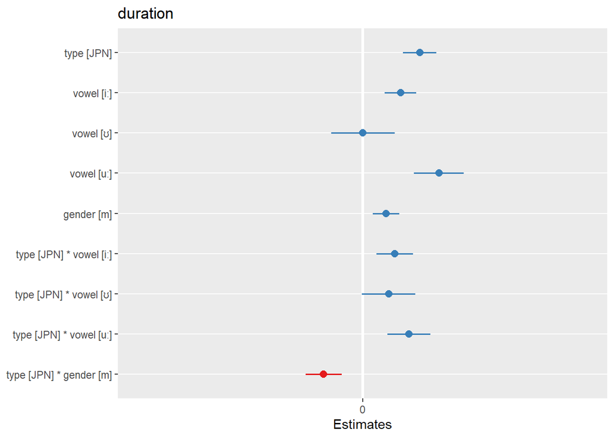

```r
sjPlot::plot_model(m10) +
  coord_flip(ylim = c(-.1, .1))
```

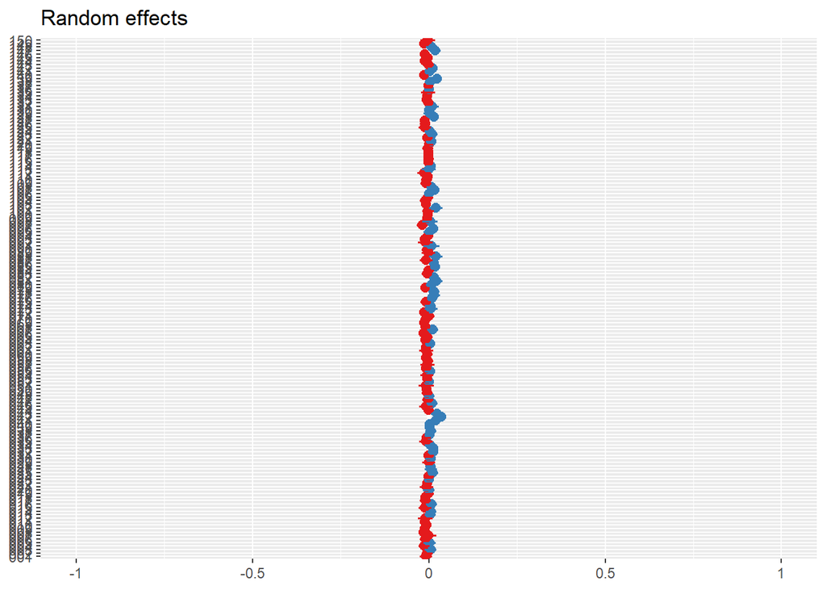

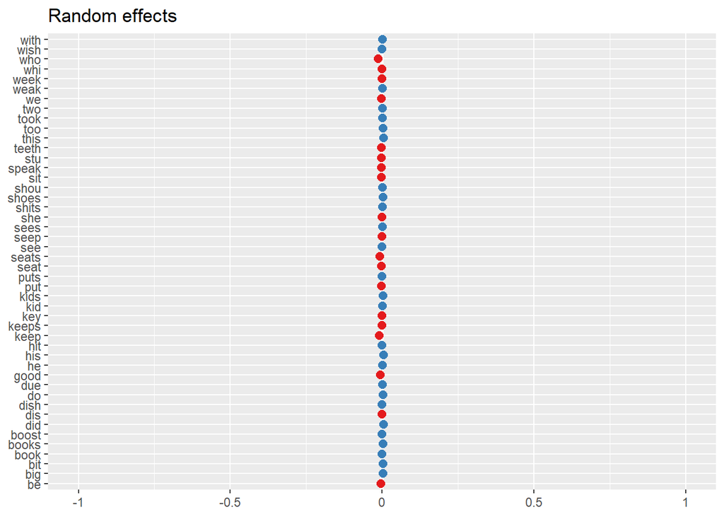

```r
plot_model(m10, type = "re", terms = "words")
```

```r
fixef(m10)
```

```
##        (Intercept)            typeJPN            voweliː             vowelʊ
##  0.059760189844393  0.025681531431042  0.017046861701776  0.000173724995203
##            voweluː            genderm    typeJPN:voweliː     typeJPN:vowelʊ
##  0.034385847220458  0.010501455458061  0.014447430206800  0.011715624166993
##    typeJPN:voweluː    typeJPN:genderm
##  0.020875809637374 -0.017546529328301
```

```r
# jpn i
jpn_I <- fixef(m10)[1] + fixef(m10)[2]
jpn_i <- fixef(m10)[1] + fixef(m10)[2] + fixef(m10)[3]  + fixef(m10)[7]
# ens i
ens_I <- fixef(m10)[1]
ens_i <- fixef(m10)[1] + fixef(m10)[3]

# jpn u
jpn_U <- fixef(m10)[1] + fixef(m10)[2] + fixef(m10)[4]  + fixef(m10)[8]
jpn_u <- fixef(m10)[1] + fixef(m10)[2] + fixef(m10)[5]  + fixef(m10)[9]
# ens i
ens_U <- fixef(m10)[1] + fixef(m10)[4]
ens_u <- fixef(m10)[1] + fixef(m10)[5]
```

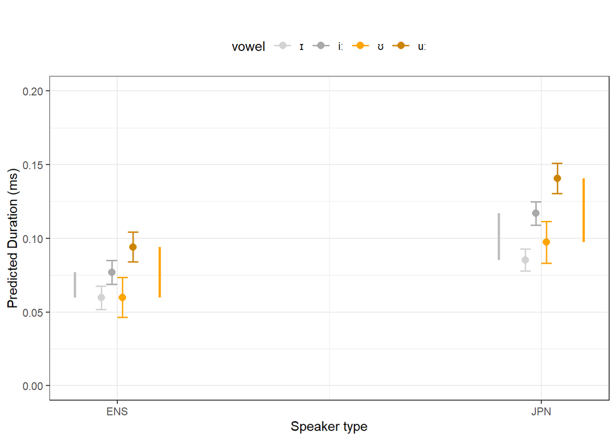

```r
plot_model(m10, type = "pred", terms = c("type", "vowel"), axis.lim = c(0, .2)) +
  theme_bw() +
  labs(x = "Speaker type", y = "Predicted Duration (ms)", title = "") +
  geom_segment(aes(x = 1.9, y = jpn_I, xend = 1.9, yend = jpn_i),
               size = 1, color = "gray") +
  geom_segment(aes(x = 0.9, y = ens_I, xend = 0.9, yend = ens_i),
               size = 1, color = "gray") +
    geom_segment(aes(x = 2.1, y = jpn_U, xend = 2.1, yend = jpn_u),
                 size = 1, color = "orange") +
  geom_segment(aes(x = 1.1, y = ens_U, xend = 1.1, yend = ens_u),
               size = 1, color = "orange") +
  scale_color_manual(values = c("lightgray", "darkgray", "orange", "orange3")) +
  theme(legend.position = "top")
```

```r
# save
ggsave(here::here("images", "ef.png"), height = 3,  width = 4, dpi = 320)
```

```r
report::report(m10)
```

# 4 Citation & Session Info

Schweinberger, Martin. 2022. Analysing Learner Speech and Resulting Applications for EFL Classrooms - A corpus-based contrastive analysis of vowel production of L1 English speakers and L1 Japanese learners of English (Part 2). Brisbane: The University of Queensland, School of Languages and Cultures. url: https://slcladal.github.io/praatrf.html (Version 2022.06.13).

@manual{schweinberger2022japevk2, author = {Schweinberger, Martin}, title = {Analysing Learner Speech and Resulting Applications for EFL Classrooms - A corpus-based contrastive analysis of vowel production of L1 English speakers and L1 Japanese learners of English (Part 2)}, note = {https://slcladal.github.io/praatrf.html}, year = {2022}, organization = “The University of Queensland, School of Languages and Cultures}, address = {Brisbane}, edition = {2022.06.13} }